# pandas

1. What is pandas?
2. How do I read a tabular data file into pandas?
3. How do I select a pandas Series from a DataFrame?
4. Why do some pandas commands end with parentheses (and others don't)?
5. How do I rename columns in a pandas DataFrame?
6. How do I remove columns from a pandas DataFrame?
7. How do I sort a pandas DataFrame or a Series?
8. How do I filter rows of a pandas DataFrame by column value?
9. How do I apply multiple filter criteria to a pandas DataFrame?
10. Your pandas questions answered!
11. How do I use the "axis" parameter in pandas?
12. How do I use string methods in pandas?
13. How do I change the data type of a pandas Series?
14. When should I use a "groupby" in pandas?
15. How do I explore a pandas Series?
16. How do I handle missing values in pandas?
17. What do I need to know about the pandas index? (Part 1)
18. What do I need to know about the pandas index? (Part 2)
19. How do I select multiple rows and columns from a pandas DataFrame?
20. When should I use the "inplace" parameter in pandas?
21. How do I make my pandas DataFrame smaller and faster?
22. How do I use pandas with scikit-learn to create Kaggle submissions?
23. More of your pandas questions answered!
24. How do I create dummy variables in pandas?
25. How do I work with dates and times in pandas?
26. How do I find and remove duplicate rows in pandas?
27. How do I avoid a SettingWithCopyWarning in pandas?

```python
# conventional way to import pandas
import pandas as pd
```

## 1. What is pandas?

- [pandas main page](http://pandas.pydata.org/)
- [pandas installation instructions](http://pandas.pydata.org/pandas-docs/stable/install.html)
- [Anaconda distribution of Python](https://www.continuum.io/downloads) (includes pandas)
- [How to use the IPython/Jupyter notebook](https://youtu.be/IsXXlYVBt1M?t=5m17s) (video)

## 2. How do I read a tabular data file into pandas?

```python
# read a dataset of Chipotle orders directly from a URL and store the results in a DataFrame
orders = pd.read_table('http://bit.ly/chiporders')
```

```python
# examine the first 5 rows
orders.head()
```

|  | order_id | quantity | item_name | choice_description | item_price |
| --- | --- | --- | --- | --- | --- |
| 0 | 1 | 1 | Chips and Fresh Tomato Salsa | NaN | $2.39 |
| 1 | 1 | 1 | Izze | [Clementine] | $3.39 |
| 2 | 1 | 1 | Nantucket Nectar | [Apple] | $3.39 |
| 3 | 1 | 1 | Chips and Tomatillo-Green Chili Salsa | NaN | $2.39 |
| 4 | 2 | 2 | Chicken Bowl | [Tomatillo-Red Chili Salsa (Hot), [Black Beans... | $16.98 |

Documentation for [**`read_table`**](http://pandas.pydata.org/pandas-docs/stable/generated/pandas.read_table.html)

```python
# read a dataset of movie reviewers (modifying the default parameter values for read_table)
user_cols = ['user_id', 'age', 'gender', 'occupation', 'zip_code']
users = pd.read_table('http://bit.ly/movieusers', sep='|', header=None, names=user_cols)
```

```python
# examine the first 5 rows
users.head()
```

|  | user_id | age | gender | occupation | zip_code |
| --- | --- | --- | --- | --- | --- |
| 0 | 1 | 24 | M | technician | 85711 |
| 1 | 2 | 53 | F | other | 94043 |
| 2 | 3 | 23 | M | writer | 32067 |
| 3 | 4 | 24 | M | technician | 43537 |
| 4 | 5 | 33 | F | other | 15213 |

[Back to top]

## 3. How do I select a pandas Series from a DataFrame? ([video](https://www.youtube.com/watch?v=zxqjeyKP2Tk&list=PL5-da3qGB5ICCsgW1MxlZ0Hq8LL5U3u9y&index=3))

```python
# read a dataset of UFO reports into a DataFrame
ufo = pd.read_table('http://bit.ly/uforeports', sep=',')
```

```python
# read_csv is equivalent to read_table, except it assumes a comma separator
ufo = pd.read_csv('http://bit.ly/uforeports')
```

```python
# examine the first 5 rows
ufo.head()
```

|  | City | Colors Reported | Shape Reported | State | Time |
| --- | --- | --- | --- | --- | --- |
| 0 | Ithaca | NaN | TRIANGLE | NY | 6/1/1930 22:00 |
| 1 | Willingboro | NaN | OTHER | NJ | 6/30/1930 20:00 |
| 2 | Holyoke | NaN | OVAL | CO | 2/15/1931 14:00 |
| 3 | Abilene | NaN | DISK | KS | 6/1/1931 13:00 |
| 4 | New York Worlds Fair | NaN | LIGHT | NY | 4/18/1933 19:00 |

```python
# select the 'City' Series using bracket notation
ufo['City']

# or equivalently, use dot notation
ufo.City
```

```
0                      Ithaca
1                 Willingboro
2                     Holyoke
3                     Abilene
4        New York Worlds Fair
5                 Valley City
6                 Crater Lake
7                        Alma
8                     Eklutna
9                     Hubbard
10                    Fontana
11                   Waterloo
12                     Belton
13                     Keokuk
14                  Ludington
```

[output cut: 47 more lines]

**Bracket notation** will always work, whereas **dot notation** has limitations:

- Dot notation doesn't work if there are **spaces** in the Series name
- Dot notation doesn't work if the Series has the same name as a **DataFrame method or attribute** (like 'head' or 'shape')
- Dot notation can't be used to define the name of a **new Series** (see below)

```python
# create a new 'Location' Series (must use bracket notation to define the Series name)
ufo['Location'] = ufo.City + ', ' + ufo.State
ufo.head()
```

|  | City | Colors Reported | Shape Reported | State | Time | Location |
| --- | --- | --- | --- | --- | --- | --- |
| 0 | Ithaca | NaN | TRIANGLE | NY | 6/1/1930 22:00 | Ithaca, NY |
| 1 | Willingboro | NaN | OTHER | NJ | 6/30/1930 20:00 | Willingboro, NJ |
| 2 | Holyoke | NaN | OVAL | CO | 2/15/1931 14:00 | Holyoke, CO |
| 3 | Abilene | NaN | DISK | KS | 6/1/1931 13:00 | Abilene, KS |
| 4 | New York Worlds Fair | NaN | LIGHT | NY | 4/18/1933 19:00 | New York Worlds Fair, NY |

[Back to top]

## 4. Why do some pandas commands end with parentheses (and others don't)? ([video](https://www.youtube.com/watch?v=hSrDViyKWVk&list=PL5-da3qGB5ICCsgW1MxlZ0Hq8LL5U3u9y&index=4))

```python
# read a dataset of top-rated IMDb movies into a DataFrame
movies = pd.read_csv('http://bit.ly/imdbratings')
```

**Methods** end with parentheses, while **attributes** don't:

```python
# example method: show the first 5 rows
movies.head()
```

|  | star_rating | title | content_rating | genre | duration | actors_list |
| --- | --- | --- | --- | --- | --- | --- |
| 0 | 9.3 | The Shawshank Redemption | R | Crime | 142 | [u'Tim Robbins', u'Morgan Freeman', u'Bob Gunt... |
| 1 | 9.2 | The Godfather | R | Crime | 175 | [u'Marlon Brando', u'Al Pacino', u'James Caan'] |
| 2 | 9.1 | The Godfather: Part II | R | Crime | 200 | [u'Al Pacino', u'Robert De Niro', u'Robert Duv... |
| 3 | 9.0 | The Dark Knight | PG-13 | Action | 152 | [u'Christian Bale', u'Heath Ledger', u'Aaron E... |
| 4 | 8.9 | Pulp Fiction | R | Crime | 154 | [u'John Travolta', u'Uma Thurman', u'Samuel L.... |

```python
# example method: calculate summary statistics
movies.describe()
```

|  | star_rating | duration |
| --- | --- | --- |
| count | 979.000000 | 979.000000 |
| mean | 7.889785 | 120.979571 |
| std | 0.336069 | 26.218010 |
| min | 7.400000 | 64.000000 |
| 25% | 7.600000 | 102.000000 |
| 50% | 7.800000 | 117.000000 |
| 75% | 8.100000 | 134.000000 |
| max | 9.300000 | 242.000000 |

```python
# example attribute: number of rows and columns
movies.shape
```

```
(979, 6)
```

```python
# example attribute: data type of each column
movies.dtypes
```

```
star_rating       float64
title              object
content_rating     object
genre              object
duration            int64
actors_list        object
dtype: object
```

```python
# use an optional parameter to the describe method to summarize only 'object' columns
movies.describe(include=['object'])
```

|  | title | content_rating | genre | actors_list |
| --- | --- | --- | --- | --- |
| count | 979 | 976 | 979 | 979 |
| unique | 975 | 12 | 16 | 969 |
| top | The Girl with the Dragon Tattoo | R | Drama | [u'Daniel Radcliffe', u'Emma Watson', u'Rupert... |
| freq | 2 | 460 | 278 | 6 |

Documentation for [**`describe`**](http://pandas.pydata.org/pandas-docs/stable/generated/pandas.DataFrame.describe.html)

[Back to top]

## 5. How do I rename columns in a pandas DataFrame? ([video](https://www.youtube.com/watch?v=0uBirYFhizE&list=PL5-da3qGB5ICCsgW1MxlZ0Hq8LL5U3u9y&index=5))

```python
# read a dataset of UFO reports into a DataFrame
ufo = pd.read_csv('http://bit.ly/uforeports')
```

```python
# examine the column names
ufo.columns
```

```
Index([u'City', u'Colors Reported', u'Shape Reported', u'State', u'Time'], dtype='object')
```

```python
# rename two of the columns by using the 'rename' method
ufo.rename(columns={'Colors Reported':'Colors_Reported', 'Shape Reported':'Shape_Reported'}, inplace=True)
ufo.columns
```

```
Index([u'City', u'Colors_Reported', u'Shape_Reported', u'State', u'Time'], dtype='object')
```

Documentation for [**`rename`**](http://pandas.pydata.org/pandas-docs/stable/generated/pandas.DataFrame.rename.html)

```python
# replace all of the column names by overwriting the 'columns' attribute
ufo_cols = ['city', 'colors reported', 'shape reported', 'state', 'time']
ufo.columns = ufo_cols
ufo.columns
```

```
Index([u'city', u'colors reported', u'shape reported', u'state', u'time'], dtype='object')
```

```python
# replace the column names during the file reading process by using the 'names' parameter
ufo = pd.read_csv('http://bit.ly/uforeports', header=0, names=ufo_cols)
ufo.columns
```

```
Index([u'city', u'colors reported', u'shape reported', u'state', u'time'], dtype='object')
```

Documentation for [**`read_csv`**](http://pandas.pydata.org/pandas-docs/stable/generated/pandas.read_csv.html)

```python
# replace all spaces with underscores in the column names by using the 'str.replace' method
ufo.columns = ufo.columns.str.replace(' ', '_')
ufo.columns
```

```
Index([u'city', u'colors_reported', u'shape_reported', u'state', u'time'], dtype='object')
```

Documentation for [**`str.replace`**](http://pandas.pydata.org/pandas-docs/stable/generated/pandas.Series.str.replace.html)

[Back to top]

## 6. How do I remove columns from a pandas DataFrame? ([video](https://www.youtube.com/watch?v=gnUKkS964WQ&list=PL5-da3qGB5ICCsgW1MxlZ0Hq8LL5U3u9y&index=6))

```python
# read a dataset of UFO reports into a DataFrame
ufo = pd.read_csv('http://bit.ly/uforeports')
ufo.head()
```

|  | City | Colors Reported | Shape Reported | State | Time |
| --- | --- | --- | --- | --- | --- |
| 0 | Ithaca | NaN | TRIANGLE | NY | 6/1/1930 22:00 |
| 1 | Willingboro | NaN | OTHER | NJ | 6/30/1930 20:00 |
| 2 | Holyoke | NaN | OVAL | CO | 2/15/1931 14:00 |
| 3 | Abilene | NaN | DISK | KS | 6/1/1931 13:00 |
| 4 | New York Worlds Fair | NaN | LIGHT | NY | 4/18/1933 19:00 |

```python
# remove a single column (axis=1 refers to columns)
ufo.drop('Colors Reported', axis=1, inplace=True)
ufo.head()
```

|  | City | Shape Reported | State | Time |
| --- | --- | --- | --- | --- |
| 0 | Ithaca | TRIANGLE | NY | 6/1/1930 22:00 |
| 1 | Willingboro | OTHER | NJ | 6/30/1930 20:00 |
| 2 | Holyoke | OVAL | CO | 2/15/1931 14:00 |
| 3 | Abilene | DISK | KS | 6/1/1931 13:00 |
| 4 | New York Worlds Fair | LIGHT | NY | 4/18/1933 19:00 |

Documentation for [**`drop`**](http://pandas.pydata.org/pandas-docs/stable/generated/pandas.DataFrame.drop.html)

```python
# remove multiple columns at once
ufo.drop(['City', 'State'], axis=1, inplace=True)
ufo.head()
```

|  | Shape Reported | Time |
| --- | --- | --- |
| 0 | TRIANGLE | 6/1/1930 22:00 |
| 1 | OTHER | 6/30/1930 20:00 |
| 2 | OVAL | 2/15/1931 14:00 |
| 3 | DISK | 6/1/1931 13:00 |
| 4 | LIGHT | 4/18/1933 19:00 |

```python
# remove multiple rows at once (axis=0 refers to rows)
ufo.drop([0, 1], axis=0, inplace=True)
ufo.head()
```

|  | Shape Reported | Time |
| --- | --- | --- |
| 2 | OVAL | 2/15/1931 14:00 |
| 3 | DISK | 6/1/1931 13:00 |
| 4 | LIGHT | 4/18/1933 19:00 |
| 5 | DISK | 9/15/1934 15:30 |
| 6 | CIRCLE | 6/15/1935 0:00 |

[Back to top]

## 7. How do I sort a pandas DataFrame or a Series? ([video](https://www.youtube.com/watch?v=zY4doF6xSxY&list=PL5-da3qGB5ICCsgW1MxlZ0Hq8LL5U3u9y&index=7))

```python
# read a dataset of top-rated IMDb movies into a DataFrame
movies = pd.read_csv('http://bit.ly/imdbratings')
movies.head()
```

|  | star_rating | title | content_rating | genre | duration | actors_list |
| --- | --- | --- | --- | --- | --- | --- |
| 0 | 9.3 | The Shawshank Redemption | R | Crime | 142 | [u'Tim Robbins', u'Morgan Freeman', u'Bob Gunt... |
| 1 | 9.2 | The Godfather | R | Crime | 175 | [u'Marlon Brando', u'Al Pacino', u'James Caan'] |
| 2 | 9.1 | The Godfather: Part II | R | Crime | 200 | [u'Al Pacino', u'Robert De Niro', u'Robert Duv... |
| 3 | 9.0 | The Dark Knight | PG-13 | Action | 152 | [u'Christian Bale', u'Heath Ledger', u'Aaron E... |
| 4 | 8.9 | Pulp Fiction | R | Crime | 154 | [u'John Travolta', u'Uma Thurman', u'Samuel L.... |

**Note:** None of the sorting methods below affect the underlying data. (In other words, the sorting is temporary).

```python
# sort the 'title' Series in ascending order (returns a Series)
movies.title.sort_values().head()
```

```
542     (500) Days of Summer
5               12 Angry Men
201         12 Years a Slave
698                127 Hours
110    2001: A Space Odyssey
Name: title, dtype: object
```

```python
# sort in descending order instead
movies.title.sort_values(ascending=False).head()
```

```
864               [Rec]
526                Zulu
615          Zombieland
677              Zodiac
955    Zero Dark Thirty
Name: title, dtype: object
```

Documentation for [**`sort_values`**](http://pandas.pydata.org/pandas-docs/stable/generated/pandas.Series.sort_values.html) for a **Series**. (Prior to version 0.17, use [**`order`**](http://pandas.pydata.org/pandas-docs/version/0.17.0/generated/pandas.Series.order.html) instead.)

```python
# sort the entire DataFrame by the 'title' Series (returns a DataFrame)
movies.sort_values('title').head()
```

|  | star_rating | title | content_rating | genre | duration | actors_list |
| --- | --- | --- | --- | --- | --- | --- |
| 542 | 7.8 | (500) Days of Summer | PG-13 | Comedy | 95 | [u'Zooey Deschanel', u'Joseph Gordon-Levitt', ... |
| 5 | 8.9 | 12 Angry Men | NOT RATED | Drama | 96 | [u'Henry Fonda', u'Lee J. Cobb', u'Martin Bals... |
| 201 | 8.1 | 12 Years a Slave | R | Biography | 134 | [u'Chiwetel Ejiofor', u'Michael Kenneth Willia... |
| 698 | 7.6 | 127 Hours | R | Adventure | 94 | [u'James Franco', u'Amber Tamblyn', u'Kate Mara'] |
| 110 | 8.3 | 2001: A Space Odyssey | G | Mystery | 160 | [u'Keir Dullea', u'Gary Lockwood', u'William S... |

```python
# sort in descending order instead
movies.sort_values('title', ascending=False).head()
```

|  | star_rating | title | content_rating | genre | duration | actors_list |
| --- | --- | --- | --- | --- | --- | --- |
| 864 | 7.5 | [Rec] | R | Horror | 78 | [u'Manuela Velasco', u'Ferran Terraza', u'Jorg... |
| 526 | 7.8 | Zulu | UNRATED | Drama | 138 | [u'Stanley Baker', u'Jack Hawkins', u'Ulla Jac... |
| 615 | 7.7 | Zombieland | R | Comedy | 88 | [u'Jesse Eisenberg', u'Emma Stone', u'Woody Ha... |
| 677 | 7.7 | Zodiac | R | Crime | 157 | [u'Jake Gyllenhaal', u'Robert Downey Jr.', u'M... |
| 955 | 7.4 | Zero Dark Thirty | R | Drama | 157 | [u'Jessica Chastain', u'Joel Edgerton', u'Chri... |

Documentation for [**`sort_values`**](http://pandas.pydata.org/pandas-docs/stable/generated/pandas.DataFrame.sort_values.html) for a **DataFrame**. (Prior to version 0.17, use [**`sort`**](http://pandas.pydata.org/pandas-docs/version/0.17.0/generated/pandas.DataFrame.sort.html) instead.)

```python
# sort the DataFrame first by 'content_rating', then by 'duration'
movies.sort_values(['content_rating', 'duration']).head()
```

|  | star_rating | title | content_rating | genre | duration | actors_list |
| --- | --- | --- | --- | --- | --- | --- |
| 713 | 7.6 | The Jungle Book | APPROVED | Animation | 78 | [u'Phil Harris', u'Sebastian Cabot', u'Louis P... |
| 513 | 7.8 | Invasion of the Body Snatchers | APPROVED | Horror | 80 | [u'Kevin McCarthy', u'Dana Wynter', u'Larry Ga... |
| 272 | 8.1 | The Killing | APPROVED | Crime | 85 | [u'Sterling Hayden', u'Coleen Gray', u'Vince E... |
| 703 | 7.6 | Dracula | APPROVED | Horror | 85 | [u'Bela Lugosi', u'Helen Chandler', u'David Ma... |
| 612 | 7.7 | A Hard Day's Night | APPROVED | Comedy | 87 | [u'John Lennon', u'Paul McCartney', u'George H... |

[Summary of changes to the sorting API](http://pandas.pydata.org/pandas-docs/stable/whatsnew.html#changes-to-sorting-api) in pandas 0.17

[Back to top]

## 8. How do I filter rows of a pandas DataFrame by column value? ([video](https://www.youtube.com/watch?v=2AFGPdNn4FM&list=PL5-da3qGB5ICCsgW1MxlZ0Hq8LL5U3u9y&index=8))

```python
# read a dataset of top-rated IMDb movies into a DataFrame
movies = pd.read_csv('http://bit.ly/imdbratings')
movies.head()
```

|  | star_rating | title | content_rating | genre | duration | actors_list |
| --- | --- | --- | --- | --- | --- | --- |
| 0 | 9.3 | The Shawshank Redemption | R | Crime | 142 | [u'Tim Robbins', u'Morgan Freeman', u'Bob Gunt... |
| 1 | 9.2 | The Godfather | R | Crime | 175 | [u'Marlon Brando', u'Al Pacino', u'James Caan'] |
| 2 | 9.1 | The Godfather: Part II | R | Crime | 200 | [u'Al Pacino', u'Robert De Niro', u'Robert Duv... |
| 3 | 9.0 | The Dark Knight | PG-13 | Action | 152 | [u'Christian Bale', u'Heath Ledger', u'Aaron E... |
| 4 | 8.9 | Pulp Fiction | R | Crime | 154 | [u'John Travolta', u'Uma Thurman', u'Samuel L.... |

```python
# examine the number of rows and columns
movies.shape
```

```
(979, 6)
```

**Goal:** Filter the DataFrame rows to only show movies with a 'duration' of at least 200 minutes.

```python
# create a list in which each element refers to a DataFrame row: True if the row satisfies the condition, False otherwise
booleans = []
for length in movies.duration:
    if length >= 200:
        booleans.append(True)
    else:
        booleans.append(False)
```

```python
# confirm that the list has the same length as the DataFrame
len(booleans)
```

```
979
```

```python
# examine the first five list elements
booleans[0:5]
```

```
[False, False, True, False, False]
```

```python
# convert the list to a Series
is_long = pd.Series(booleans)
is_long.head()
```

```
0    False
1    False
2     True
3    False
4    False
dtype: bool
```

```python
# use bracket notation with the boolean Series to tell the DataFrame which rows to display
movies[is_long]
```

|  | star_rating | title | content_rating | genre | duration | actors_list |
| --- | --- | --- | --- | --- | --- | --- |
| 2 | 9.1 | The Godfather: Part II | R | Crime | 200 | [u'Al Pacino', u'Robert De Niro', u'Robert Duv... |
| 7 | 8.9 | The Lord of the Rings: The Return of the King | PG-13 | Adventure | 201 | [u'Elijah Wood', u'Viggo Mortensen', u'Ian McK... |
| 17 | 8.7 | Seven Samurai | UNRATED | Drama | 207 | [u'Toshir\xf4 Mifune', u'Takashi Shimura', u'K... |
| 78 | 8.4 | Once Upon a Time in America | R | Crime | 229 | [u'Robert De Niro', u'James Woods', u'Elizabet... |
| 85 | 8.4 | Lawrence of Arabia | PG | Adventure | 216 | [u"Peter O'Toole", u'Alec Guinness', u'Anthony... |
| 142 | 8.3 | Lagaan: Once Upon a Time in India | PG | Adventure | 224 | [u'Aamir Khan', u'Gracy Singh', u'Rachel Shell... |
| 157 | 8.2 | Gone with the Wind | G | Drama | 238 | [u'Clark Gable', u'Vivien Leigh', u'Thomas Mit... |
| 204 | 8.1 | Ben-Hur | G | Adventure | 212 | [u'Charlton Heston', u'Jack Hawkins', u'Stephe... |
| 445 | 7.9 | The Ten Commandments | APPROVED | Adventure | 220 | [u'Charlton Heston', u'Yul Brynner', u'Anne Ba... |
| 476 | 7.8 | Hamlet | PG-13 | Drama | 242 | [u'Kenneth Branagh', u'Julie Christie', u'Dere... |
| 630 | 7.7 | Malcolm X | PG-13 | Biography | 202 | [u'Denzel Washington', u'Angela Bassett', u'De... |
| 767 | 7.6 | It's a Mad, Mad, Mad, Mad World | APPROVED | Action | 205 | [u'Spencer Tracy', u'Milton Berle', u'Ethel Me... |

```python
# simplify the steps above: no need to write a for loop to create 'is_long' since pandas will broadcast the comparison
is_long = movies.duration >= 200
movies[is_long]

# or equivalently, write it in one line (no need to create the 'is_long' object)
movies[movies.duration >= 200]
```

|  | star_rating | title | content_rating | genre | duration | actors_list |
| --- | --- | --- | --- | --- | --- | --- |
| 2 | 9.1 | The Godfather: Part II | R | Crime | 200 | [u'Al Pacino', u'Robert De Niro', u'Robert Duv... |
| 7 | 8.9 | The Lord of the Rings: The Return of the King | PG-13 | Adventure | 201 | [u'Elijah Wood', u'Viggo Mortensen', u'Ian McK... |
| 17 | 8.7 | Seven Samurai | UNRATED | Drama | 207 | [u'Toshir\xf4 Mifune', u'Takashi Shimura', u'K... |
| 78 | 8.4 | Once Upon a Time in America | R | Crime | 229 | [u'Robert De Niro', u'James Woods', u'Elizabet... |
| 85 | 8.4 | Lawrence of Arabia | PG | Adventure | 216 | [u"Peter O'Toole", u'Alec Guinness', u'Anthony... |
| 142 | 8.3 | Lagaan: Once Upon a Time in India | PG | Adventure | 224 | [u'Aamir Khan', u'Gracy Singh', u'Rachel Shell... |
| 157 | 8.2 | Gone with the Wind | G | Drama | 238 | [u'Clark Gable', u'Vivien Leigh', u'Thomas Mit... |
| 204 | 8.1 | Ben-Hur | G | Adventure | 212 | [u'Charlton Heston', u'Jack Hawkins', u'Stephe... |
| 445 | 7.9 | The Ten Commandments | APPROVED | Adventure | 220 | [u'Charlton Heston', u'Yul Brynner', u'Anne Ba... |
| 476 | 7.8 | Hamlet | PG-13 | Drama | 242 | [u'Kenneth Branagh', u'Julie Christie', u'Dere... |
| 630 | 7.7 | Malcolm X | PG-13 | Biography | 202 | [u'Denzel Washington', u'Angela Bassett', u'De... |
| 767 | 7.6 | It's a Mad, Mad, Mad, Mad World | APPROVED | Action | 205 | [u'Spencer Tracy', u'Milton Berle', u'Ethel Me... |

```python
# select the 'genre' Series from the filtered DataFrame
movies[movies.duration >= 200].genre

# or equivalently, use the 'loc' method
movies.loc[movies.duration >= 200, 'genre']
```

```
2          Crime
7      Adventure
17         Drama
78         Crime
85     Adventure
142    Adventure
157        Drama
204    Adventure
445    Adventure
476        Drama
630    Biography
767       Action
Name: genre, dtype: object
```

Documentation for [**`loc`**](http://pandas.pydata.org/pandas-docs/stable/generated/pandas.DataFrame.loc.html)

[Back to top]

## 9. How do I apply multiple filter criteria to a pandas DataFrame? ([video](https://www.youtube.com/watch?v=YPItfQ87qjM&list=PL5-da3qGB5ICCsgW1MxlZ0Hq8LL5U3u9y&index=9))

```python
# read a dataset of top-rated IMDb movies into a DataFrame
movies = pd.read_csv('http://bit.ly/imdbratings')
movies.head()
```

|  | star_rating | title | content_rating | genre | duration | actors_list |
| --- | --- | --- | --- | --- | --- | --- |
| 0 | 9.3 | The Shawshank Redemption | R | Crime | 142 | [u'Tim Robbins', u'Morgan Freeman', u'Bob Gunt... |
| 1 | 9.2 | The Godfather | R | Crime | 175 | [u'Marlon Brando', u'Al Pacino', u'James Caan'] |
| 2 | 9.1 | The Godfather: Part II | R | Crime | 200 | [u'Al Pacino', u'Robert De Niro', u'Robert Duv... |
| 3 | 9.0 | The Dark Knight | PG-13 | Action | 152 | [u'Christian Bale', u'Heath Ledger', u'Aaron E... |
| 4 | 8.9 | Pulp Fiction | R | Crime | 154 | [u'John Travolta', u'Uma Thurman', u'Samuel L.... |

```python
# filter the DataFrame to only show movies with a 'duration' of at least 200 minutes
movies[movies.duration >= 200]
```

|  | star_rating | title | content_rating | genre | duration | actors_list |
| --- | --- | --- | --- | --- | --- | --- |
| 2 | 9.1 | The Godfather: Part II | R | Crime | 200 | [u'Al Pacino', u'Robert De Niro', u'Robert Duv... |
| 7 | 8.9 | The Lord of the Rings: The Return of the King | PG-13 | Adventure | 201 | [u'Elijah Wood', u'Viggo Mortensen', u'Ian McK... |
| 17 | 8.7 | Seven Samurai | UNRATED | Drama | 207 | [u'Toshir\xf4 Mifune', u'Takashi Shimura', u'K... |
| 78 | 8.4 | Once Upon a Time in America | R | Crime | 229 | [u'Robert De Niro', u'James Woods', u'Elizabet... |
| 85 | 8.4 | Lawrence of Arabia | PG | Adventure | 216 | [u"Peter O'Toole", u'Alec Guinness', u'Anthony... |
| 142 | 8.3 | Lagaan: Once Upon a Time in India | PG | Adventure | 224 | [u'Aamir Khan', u'Gracy Singh', u'Rachel Shell... |
| 157 | 8.2 | Gone with the Wind | G | Drama | 238 | [u'Clark Gable', u'Vivien Leigh', u'Thomas Mit... |
| 204 | 8.1 | Ben-Hur | G | Adventure | 212 | [u'Charlton Heston', u'Jack Hawkins', u'Stephe... |
| 445 | 7.9 | The Ten Commandments | APPROVED | Adventure | 220 | [u'Charlton Heston', u'Yul Brynner', u'Anne Ba... |
| 476 | 7.8 | Hamlet | PG-13 | Drama | 242 | [u'Kenneth Branagh', u'Julie Christie', u'Dere... |
| 630 | 7.7 | Malcolm X | PG-13 | Biography | 202 | [u'Denzel Washington', u'Angela Bassett', u'De... |
| 767 | 7.6 | It's a Mad, Mad, Mad, Mad World | APPROVED | Action | 205 | [u'Spencer Tracy', u'Milton Berle', u'Ethel Me... |

Understanding **logical operators:**

- **`and`**: True only if **both sides** of the operator are True
- **`or`**: True if **either side** of the operator is True

```python
# demonstration of the 'and' operator
print(True and True)
print(True and False)
print(False and False)
```

```
True
False
False
```

```python
# demonstration of the 'or' operator
print(True or True)
print(True or False)
print(False or False)
```

```
True
True
False
```

Rules for specifying **multiple filter criteria** in pandas:

- use **`&`** instead of **`and`**
- use **`|`** instead of **`or`**
- add **parentheses** around each condition to specify evaluation order

**Goal:** Further filter the DataFrame of long movies (duration >= 200) to only show movies which also have a 'genre' of 'Drama'

```python
# CORRECT: use the '&' operator to specify that both conditions are required
movies[(movies.duration >=200) & (movies.genre == 'Drama')]
```

|  | star_rating | title | content_rating | genre | duration | actors_list |
| --- | --- | --- | --- | --- | --- | --- |
| 17 | 8.7 | Seven Samurai | UNRATED | Drama | 207 | [u'Toshir\xf4 Mifune', u'Takashi Shimura', u'K... |
| 157 | 8.2 | Gone with the Wind | G | Drama | 238 | [u'Clark Gable', u'Vivien Leigh', u'Thomas Mit... |
| 476 | 7.8 | Hamlet | PG-13 | Drama | 242 | [u'Kenneth Branagh', u'Julie Christie', u'Dere... |

```python
# INCORRECT: using the '|' operator would have shown movies that are either long or dramas (or both)
movies[(movies.duration >=200) | (movies.genre == 'Drama')].head()
```

|  | star_rating | title | content_rating | genre | duration | actors_list |
| --- | --- | --- | --- | --- | --- | --- |
| 2 | 9.1 | The Godfather: Part II | R | Crime | 200 | [u'Al Pacino', u'Robert De Niro', u'Robert Duv... |
| 5 | 8.9 | 12 Angry Men | NOT RATED | Drama | 96 | [u'Henry Fonda', u'Lee J. Cobb', u'Martin Bals... |
| 7 | 8.9 | The Lord of the Rings: The Return of the King | PG-13 | Adventure | 201 | [u'Elijah Wood', u'Viggo Mortensen', u'Ian McK... |
| 9 | 8.9 | Fight Club | R | Drama | 139 | [u'Brad Pitt', u'Edward Norton', u'Helena Bonh... |
| 13 | 8.8 | Forrest Gump | PG-13 | Drama | 142 | [u'Tom Hanks', u'Robin Wright', u'Gary Sinise'] |

**Goal:** Filter the original DataFrame to show movies with a 'genre' of 'Crime' or 'Drama' or 'Action'

```python
# use the '|' operator to specify that a row can match any of the three criteria
movies[(movies.genre == 'Crime') | (movies.genre == 'Drama') | (movies.genre == 'Action')].head(10)

# or equivalently, use the 'isin' method
movies[movies.genre.isin(['Crime', 'Drama', 'Action'])].head(10)
```

|  | star_rating | title | content_rating | genre | duration | actors_list |
| --- | --- | --- | --- | --- | --- | --- |
| 0 | 9.3 | The Shawshank Redemption | R | Crime | 142 | [u'Tim Robbins', u'Morgan Freeman', u'Bob Gunt... |
| 1 | 9.2 | The Godfather | R | Crime | 175 | [u'Marlon Brando', u'Al Pacino', u'James Caan'] |
| 2 | 9.1 | The Godfather: Part II | R | Crime | 200 | [u'Al Pacino', u'Robert De Niro', u'Robert Duv... |
| 3 | 9.0 | The Dark Knight | PG-13 | Action | 152 | [u'Christian Bale', u'Heath Ledger', u'Aaron E... |
| 4 | 8.9 | Pulp Fiction | R | Crime | 154 | [u'John Travolta', u'Uma Thurman', u'Samuel L.... |
| 5 | 8.9 | 12 Angry Men | NOT RATED | Drama | 96 | [u'Henry Fonda', u'Lee J. Cobb', u'Martin Bals... |
| 9 | 8.9 | Fight Club | R | Drama | 139 | [u'Brad Pitt', u'Edward Norton', u'Helena Bonh... |
| 11 | 8.8 | Inception | PG-13 | Action | 148 | [u'Leonardo DiCaprio', u'Joseph Gordon-Levitt'... |
| 12 | 8.8 | Star Wars: Episode V - The Empire Strikes Back | PG | Action | 124 | [u'Mark Hamill', u'Harrison Ford', u'Carrie Fi... |
| 13 | 8.8 | Forrest Gump | PG-13 | Drama | 142 | [u'Tom Hanks', u'Robin Wright', u'Gary Sinise'] |

Documentation for [**`isin`**](http://pandas.pydata.org/pandas-docs/stable/generated/pandas.Series.isin.html)

[Back to top]

## 10. Your pandas questions answered! ([video](https://www.youtube.com/watch?v=B-r9VuK80dk&list=PL5-da3qGB5ICCsgW1MxlZ0Hq8LL5U3u9y&index=10))

**Question:** When reading from a file, how do I read in only a subset of the columns?

```python
# read a dataset of UFO reports into a DataFrame, and check the columns
ufo = pd.read_csv('http://bit.ly/uforeports')
ufo.columns
```

```
Index([u'City', u'Colors Reported', u'Shape Reported', u'State', u'Time'], dtype='object')
```

```python
# specify which columns to include by name
ufo = pd.read_csv('http://bit.ly/uforeports', usecols=['City', 'State'])

# or equivalently, specify columns by position
ufo = pd.read_csv('http://bit.ly/uforeports', usecols=[0, 4])
ufo.columns
```

```
Index([u'City', u'Time'], dtype='object')
```

**Question:** When reading from a file, how do I read in only a subset of the rows?

```python
# specify how many rows to read
ufo = pd.read_csv('http://bit.ly/uforeports', nrows=3)
ufo
```

|  | City | Colors Reported | Shape Reported | State | Time |
| --- | --- | --- | --- | --- | --- |
| 0 | Ithaca | NaN | TRIANGLE | NY | 6/1/1930 22:00 |
| 1 | Willingboro | NaN | OTHER | NJ | 6/30/1930 20:00 |
| 2 | Holyoke | NaN | OVAL | CO | 2/15/1931 14:00 |

Documentation for [**`read_csv`**](http://pandas.pydata.org/pandas-docs/stable/generated/pandas.read_csv.html)

**Question:** How do I iterate through a Series?

```python
# Series are directly iterable (like a list)
for c in ufo.City:
    print(c)
```

```
Ithaca
Willingboro
Holyoke
```

**Question:** How do I iterate through a DataFrame?

```python
# various methods are available to iterate through a DataFrame
for index, row in ufo.iterrows():
    print(index, row.City, row.State)
```

```
(0, 'Ithaca', 'NY')
(1, 'Willingboro', 'NJ')
(2, 'Holyoke', 'CO')
```

Documentation for [**`iterrows`**](http://pandas.pydata.org/pandas-docs/stable/generated/pandas.DataFrame.iterrows.html)

**Question:** How do I drop all non-numeric columns from a DataFrame?

```python
# read a dataset of alcohol consumption into a DataFrame, and check the data types
drinks = pd.read_csv('http://bit.ly/drinksbycountry')
drinks.dtypes
```

```
country                          object
beer_servings                     int64
spirit_servings                   int64
wine_servings                     int64
total_litres_of_pure_alcohol    float64
continent                        object
dtype: object
```

```python
# only include numeric columns in the DataFrame
import numpy as np
drinks.select_dtypes(include=[np.number]).dtypes
```

```
beer_servings                     int64
spirit_servings                   int64
wine_servings                     int64
total_litres_of_pure_alcohol    float64
dtype: object
```

Documentation for [**`select_dtypes`**](http://pandas.pydata.org/pandas-docs/stable/generated/pandas.DataFrame.select_dtypes.html)

**Question:** How do I know whether I should pass an argument as a string or a list?

```python
# describe all of the numeric columns
drinks.describe()
```

|  | beer_servings | spirit_servings | wine_servings | total_litres_of_pure_alcohol |
| --- | --- | --- | --- | --- |
| count | 193.000000 | 193.000000 | 193.000000 | 193.000000 |
| mean | 106.160622 | 80.994819 | 49.450777 | 4.717098 |
| std | 101.143103 | 88.284312 | 79.697598 | 3.773298 |
| min | 0.000000 | 0.000000 | 0.000000 | 0.000000 |
| 25% | 20.000000 | 4.000000 | 1.000000 | 1.300000 |
| 50% | 76.000000 | 56.000000 | 8.000000 | 4.200000 |
| 75% | 188.000000 | 128.000000 | 59.000000 | 7.200000 |
| max | 376.000000 | 438.000000 | 370.000000 | 14.400000 |

```python
# pass the string 'all' to describe all columns
drinks.describe(include='all')
```

|  | country | beer_servings | spirit_servings | wine_servings | total_litres_of_pure_alcohol | continent |
| --- | --- | --- | --- | --- | --- | --- |
| count | 193 | 193.000000 | 193.000000 | 193.000000 | 193.000000 | 193 |
| unique | 193 | NaN | NaN | NaN | NaN | 6 |
| top | Lesotho | NaN | NaN | NaN | NaN | Africa |
| freq | 1 | NaN | NaN | NaN | NaN | 53 |
| mean | NaN | 106.160622 | 80.994819 | 49.450777 | 4.717098 | NaN |
| std | NaN | 101.143103 | 88.284312 | 79.697598 | 3.773298 | NaN |
| min | NaN | 0.000000 | 0.000000 | 0.000000 | 0.000000 | NaN |
| 25% | NaN | 20.000000 | 4.000000 | 1.000000 | 1.300000 | NaN |
| 50% | NaN | 76.000000 | 56.000000 | 8.000000 | 4.200000 | NaN |
| 75% | NaN | 188.000000 | 128.000000 | 59.000000 | 7.200000 | NaN |
| max | NaN | 376.000000 | 438.000000 | 370.000000 | 14.400000 | NaN |

```python
# pass a list of data types to only describe certain types
drinks.describe(include=['object', 'float64'])
```

|  | country | total_litres_of_pure_alcohol | continent |
| --- | --- | --- | --- |
| count | 193 | 193.000000 | 193 |
| unique | 193 | NaN | 6 |
| top | Lesotho | NaN | Africa |
| freq | 1 | NaN | 53 |
| mean | NaN | 4.717098 | NaN |
| std | NaN | 3.773298 | NaN |
| min | NaN | 0.000000 | NaN |
| 25% | NaN | 1.300000 | NaN |
| 50% | NaN | 4.200000 | NaN |
| 75% | NaN | 7.200000 | NaN |
| max | NaN | 14.400000 | NaN |

```python
# pass a list even if you only want to describe a single data type
drinks.describe(include=['object'])
```

|  | country | continent |
| --- | --- | --- |
| count | 193 | 193 |
| unique | 193 | 6 |
| top | Lesotho | Africa |
| freq | 1 | 53 |

Documentation for [**`describe`**](http://pandas.pydata.org/pandas-docs/stable/generated/pandas.DataFrame.describe.html)

[Back to top]

## 11. How do I use the "axis" parameter in pandas? ([video](https://www.youtube.com/watch?v=PtO3t6ynH-8&list=PL5-da3qGB5ICCsgW1MxlZ0Hq8LL5U3u9y&index=11))

```python
# read a dataset of alcohol consumption into a DataFrame
drinks = pd.read_csv('http://bit.ly/drinksbycountry')
drinks.head()
```

|  | country | beer_servings | spirit_servings | wine_servings | total_litres_of_pure_alcohol | continent |
| --- | --- | --- | --- | --- | --- | --- |
| 0 | Afghanistan | 0 | 0 | 0 | 0.0 | Asia |
| 1 | Albania | 89 | 132 | 54 | 4.9 | Europe |
| 2 | Algeria | 25 | 0 | 14 | 0.7 | Africa |
| 3 | Andorra | 245 | 138 | 312 | 12.4 | Europe |
| 4 | Angola | 217 | 57 | 45 | 5.9 | Africa |

```python
# drop a column (temporarily)
drinks.drop('continent', axis=1).head()
```

|  | country | beer_servings | spirit_servings | wine_servings | total_litres_of_pure_alcohol |
| --- | --- | --- | --- | --- | --- |
| 0 | Afghanistan | 0 | 0 | 0 | 0.0 |
| 1 | Albania | 89 | 132 | 54 | 4.9 |
| 2 | Algeria | 25 | 0 | 14 | 0.7 |
| 3 | Andorra | 245 | 138 | 312 | 12.4 |
| 4 | Angola | 217 | 57 | 45 | 5.9 |

Documentation for [**`drop`**](http://pandas.pydata.org/pandas-docs/stable/generated/pandas.DataFrame.drop.html)

```python
# drop a row (temporarily)
drinks.drop(2, axis=0).head()
```

|  | country | beer_servings | spirit_servings | wine_servings | total_litres_of_pure_alcohol | continent |
| --- | --- | --- | --- | --- | --- | --- |
| 0 | Afghanistan | 0 | 0 | 0 | 0.0 | Asia |
| 1 | Albania | 89 | 132 | 54 | 4.9 | Europe |
| 3 | Andorra | 245 | 138 | 312 | 12.4 | Europe |
| 4 | Angola | 217 | 57 | 45 | 5.9 | Africa |
| 5 | Antigua & Barbuda | 102 | 128 | 45 | 4.9 | North America |

When **referring to rows or columns** with the axis parameter:

- **axis 0** refers to rows
- **axis 1** refers to columns

```python
# calculate the mean of each numeric column
drinks.mean()

# or equivalently, specify the axis explicitly
drinks.mean(axis=0)
```

```
beer_servings                   106.160622
spirit_servings                  80.994819
wine_servings                    49.450777
total_litres_of_pure_alcohol      4.717098
dtype: float64
```

Documentation for [**`mean`**](http://pandas.pydata.org/pandas-docs/stable/generated/pandas.DataFrame.mean.html)

```python
# calculate the mean of each row
drinks.mean(axis=1).head()
```

```
0      0.000
1     69.975
2      9.925
3    176.850
4     81.225
dtype: float64
```

When performing a **mathematical operation** with the axis parameter:

- **axis 0** means the operation should "move down" the row axis
- **axis 1** means the operation should "move across" the column axis

```python
# 'index' is an alias for axis 0
drinks.mean(axis='index')
```

```
beer_servings                   106.160622
spirit_servings                  80.994819
wine_servings                    49.450777
total_litres_of_pure_alcohol      4.717098
dtype: float64
```

```python
# 'columns' is an alias for axis 1
drinks.mean(axis='columns').head()
```

```
0      0.000
1     69.975
2      9.925
3    176.850
4     81.225
dtype: float64
```

[Back to top]

## 12. How do I use string methods in pandas? ([video](https://www.youtube.com/watch?v=bofaC0IckHo&list=PL5-da3qGB5ICCsgW1MxlZ0Hq8LL5U3u9y&index=12))

```python
# read a dataset of Chipotle orders into a DataFrame
orders = pd.read_table('http://bit.ly/chiporders')
orders.head()
```

|  | order_id | quantity | item_name | choice_description | item_price |
| --- | --- | --- | --- | --- | --- |
| 0 | 1 | 1 | Chips and Fresh Tomato Salsa | NaN | $2.39 |
| 1 | 1 | 1 | Izze | [Clementine] | $3.39 |
| 2 | 1 | 1 | Nantucket Nectar | [Apple] | $3.39 |
| 3 | 1 | 1 | Chips and Tomatillo-Green Chili Salsa | NaN | $2.39 |
| 4 | 2 | 2 | Chicken Bowl | [Tomatillo-Red Chili Salsa (Hot), [Black Beans... | $16.98 |

```python
# normal way to access string methods in Python
'hello'.upper()
```

```
'HELLO'
```

```python
# string methods for pandas Series are accessed via 'str'
orders.item_name.str.upper().head()
```

```
0             CHIPS AND FRESH TOMATO SALSA
1                                     IZZE
2                         NANTUCKET NECTAR
3    CHIPS AND TOMATILLO-GREEN CHILI SALSA
4                             CHICKEN BOWL
Name: item_name, dtype: object
```

```python
# string method 'contains' checks for a substring and returns a boolean Series
orders.item_name.str.contains('Chicken').head()
```

```
0    False
1    False
2    False
3    False
4     True
Name: item_name, dtype: bool
```

```python
# use the boolean Series to filter the DataFrame
orders[orders.item_name.str.contains('Chicken')].head()
```

|  | order_id | quantity | item_name | choice_description | item_price |
| --- | --- | --- | --- | --- | --- |
| 4 | 2 | 2 | Chicken Bowl | [Tomatillo-Red Chili Salsa (Hot), [Black Beans... | $16.98 |
| 5 | 3 | 1 | Chicken Bowl | [Fresh Tomato Salsa (Mild), [Rice, Cheese, Sou... | $10.98 |
| 11 | 6 | 1 | Chicken Crispy Tacos | [Roasted Chili Corn Salsa, [Fajita Vegetables,... | $8.75 |
| 12 | 6 | 1 | Chicken Soft Tacos | [Roasted Chili Corn Salsa, [Rice, Black Beans,... | $8.75 |
| 13 | 7 | 1 | Chicken Bowl | [Fresh Tomato Salsa, [Fajita Vegetables, Rice,... | $11.25 |

```python
# string methods can be chained together
orders.choice_description.str.replace('[', '').str.replace(']', '').head()
```

```
0                                                  NaN
1                                           Clementine
2                                                Apple
3                                                  NaN
4    Tomatillo-Red Chili Salsa (Hot), Black Beans, ...
Name: choice_description, dtype: object
```

```python
# many pandas string methods support regular expressions (regex)
orders.choice_description.str.replace('[\[\]]', '').head()
```

```
0                                                  NaN
1                                           Clementine
2                                                Apple
3                                                  NaN
4    Tomatillo-Red Chili Salsa (Hot), Black Beans, ...
Name: choice_description, dtype: object
```

[String handling section](http://pandas.pydata.org/pandas-docs/stable/api.html#string-handling) of the pandas API reference

[Back to top]

## 13. How do I change the data type of a pandas Series? ([video](https://www.youtube.com/watch?v=V0AWyzVMf54&list=PL5-da3qGB5ICCsgW1MxlZ0Hq8LL5U3u9y&index=13))

```python
# read a dataset of alcohol consumption into a DataFrame
drinks = pd.read_csv('http://bit.ly/drinksbycountry')
drinks.head()
```

|  | country | beer_servings | spirit_servings | wine_servings | total_litres_of_pure_alcohol | continent |
| --- | --- | --- | --- | --- | --- | --- |
| 0 | Afghanistan | 0 | 0 | 0 | 0.0 | Asia |
| 1 | Albania | 89 | 132 | 54 | 4.9 | Europe |
| 2 | Algeria | 25 | 0 | 14 | 0.7 | Africa |
| 3 | Andorra | 245 | 138 | 312 | 12.4 | Europe |
| 4 | Angola | 217 | 57 | 45 | 5.9 | Africa |

```python
# examine the data type of each Series
drinks.dtypes
```

```
country                          object
beer_servings                     int64
spirit_servings                   int64
wine_servings                     int64
total_litres_of_pure_alcohol    float64
continent                        object
dtype: object
```

```python
# change the data type of an existing Series
drinks['beer_servings'] = drinks.beer_servings.astype(float)
drinks.dtypes
```

```
country                          object
beer_servings                   float64
spirit_servings                   int64
wine_servings                     int64
total_litres_of_pure_alcohol    float64
continent                        object
dtype: object
```

Documentation for [**`astype`**](http://pandas.pydata.org/pandas-docs/stable/generated/pandas.Series.astype.html)

```python
# alternatively, change the data type of a Series while reading in a file
drinks = pd.read_csv('http://bit.ly/drinksbycountry', dtype={'beer_servings':float})
drinks.dtypes
```

```
country                          object
beer_servings                   float64
spirit_servings                   int64
wine_servings                     int64
total_litres_of_pure_alcohol    float64
continent                        object
dtype: object
```

```python
# read a dataset of Chipotle orders into a DataFrame
orders = pd.read_table('http://bit.ly/chiporders')
orders.head()
```

|  | order_id | quantity | item_name | choice_description | item_price |
| --- | --- | --- | --- | --- | --- |
| 0 | 1 | 1 | Chips and Fresh Tomato Salsa | NaN | $2.39 |
| 1 | 1 | 1 | Izze | [Clementine] | $3.39 |
| 2 | 1 | 1 | Nantucket Nectar | [Apple] | $3.39 |
| 3 | 1 | 1 | Chips and Tomatillo-Green Chili Salsa | NaN | $2.39 |
| 4 | 2 | 2 | Chicken Bowl | [Tomatillo-Red Chili Salsa (Hot), [Black Beans... | $16.98 |

```python
# examine the data type of each Series
orders.dtypes
```

```
order_id               int64
quantity               int64
item_name             object
choice_description    object
item_price            object
dtype: object
```

```python
# convert a string to a number in order to do math
orders.item_price.str.replace('$', '').astype(float).mean()
```

```
7.464335785374397
```

```python
# string method 'contains' checks for a substring and returns a boolean Series
orders.item_name.str.contains('Chicken').head()
```

```
0    False
1    False
2    False
3    False
4     True
Name: item_name, dtype: bool
```

```python
# convert a boolean Series to an integer (False = 0, True = 1)
orders.item_name.str.contains('Chicken').astype(int).head()
```

```
0    0
1    0
2    0
3    0
4    1
Name: item_name, dtype: int32
```

[Back to top]

## 14. When should I use a "groupby" in pandas? ([video](https://www.youtube.com/watch?v=qy0fDqoMJx8&list=PL5-da3qGB5ICCsgW1MxlZ0Hq8LL5U3u9y&index=14))

```python
# read a dataset of alcohol consumption into a DataFrame
drinks = pd.read_csv('http://bit.ly/drinksbycountry')
drinks.head()
```

|  | country | beer_servings | spirit_servings | wine_servings | total_litres_of_pure_alcohol | continent |
| --- | --- | --- | --- | --- | --- | --- |
| 0 | Afghanistan | 0 | 0 | 0 | 0.0 | Asia |
| 1 | Albania | 89 | 132 | 54 | 4.9 | Europe |
| 2 | Algeria | 25 | 0 | 14 | 0.7 | Africa |
| 3 | Andorra | 245 | 138 | 312 | 12.4 | Europe |
| 4 | Angola | 217 | 57 | 45 | 5.9 | Africa |

```python
# calculate the mean beer servings across the entire dataset
drinks.beer_servings.mean()
```

```
106.16062176165804
```

```python
# calculate the mean beer servings just for countries in Africa
drinks[drinks.continent=='Africa'].beer_servings.mean()
```

```
61.471698113207545
```

```python
# calculate the mean beer servings for each continent
drinks.groupby('continent').beer_servings.mean()
```

```
continent
Africa            61.471698
Asia              37.045455
Europe           193.777778
North America    145.434783
Oceania           89.687500
South America    175.083333
Name: beer_servings, dtype: float64
```

Documentation for [**`groupby`**](http://pandas.pydata.org/pandas-docs/stable/generated/pandas.DataFrame.groupby.html)

```python
# other aggregation functions (such as 'max') can also be used with groupby
drinks.groupby('continent').beer_servings.max()
```

```
continent
Africa           376
Asia             247
Europe           361
North America    285
Oceania          306
South America    333
Name: beer_servings, dtype: int64
```

```python
# multiple aggregation functions can be applied simultaneously
drinks.groupby('continent').beer_servings.agg(['count', 'mean', 'min', 'max'])
```

| continent | count | mean | min | max |
| --- | --- | --- | --- | --- |
| Africa | 53 | 61.471698 | 0 | 376 |
| Asia | 44 | 37.045455 | 0 | 247 |
| Europe | 45 | 193.777778 | 0 | 361 |
| North America | 23 | 145.434783 | 1 | 285 |
| Oceania | 16 | 89.687500 | 0 | 306 |
| South America | 12 | 175.083333 | 93 | 333 |

Documentation for [**`agg`**](http://pandas.pydata.org/pandas-docs/stable/generated/pandas.core.groupby.DataFrameGroupBy.agg.html)

```python
# specifying a column to which the aggregation function should be applied is not required
drinks.groupby('continent').mean()
```

| continent | beer_servings | spirit_servings | wine_servings | total_litres_of_pure_alcohol |
| --- | --- | --- | --- | --- |
| Africa | 61.471698 | 16.339623 | 16.264151 | 3.007547 |
| Asia | 37.045455 | 60.840909 | 9.068182 | 2.170455 |
| Europe | 193.777778 | 132.555556 | 142.222222 | 8.617778 |
| North America | 145.434783 | 165.739130 | 24.521739 | 5.995652 |
| Oceania | 89.687500 | 58.437500 | 35.625000 | 3.381250 |
| South America | 175.083333 | 114.750000 | 62.416667 | 6.308333 |

```python
# allow plots to appear in the notebook
%matplotlib inline
```

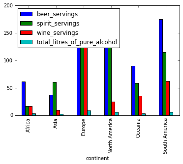

```python
# side-by-side bar plot of the DataFrame directly above
drinks.groupby('continent').mean().plot(kind='bar')
```

Documentation for [**`plot`**](http://pandas.pydata.org/pandas-docs/stable/generated/pandas.DataFrame.plot.html)

[Back to top]

## 15. How do I explore a pandas Series? ([video](https://www.youtube.com/watch?v=QTVTq8SPzxM&list=PL5-da3qGB5ICCsgW1MxlZ0Hq8LL5U3u9y&index=15))

```python
# read a dataset of top-rated IMDb movies into a DataFrame
movies = pd.read_csv('http://bit.ly/imdbratings')
movies.head()
```

|  | star_rating | title | content_rating | genre | duration | actors_list |
| --- | --- | --- | --- | --- | --- | --- |
| 0 | 9.3 | The Shawshank Redemption | R | Crime | 142 | [u'Tim Robbins', u'Morgan Freeman', u'Bob Gunt... |
| 1 | 9.2 | The Godfather | R | Crime | 175 | [u'Marlon Brando', u'Al Pacino', u'James Caan'] |
| 2 | 9.1 | The Godfather: Part II | R | Crime | 200 | [u'Al Pacino', u'Robert De Niro', u'Robert Duv... |
| 3 | 9.0 | The Dark Knight | PG-13 | Action | 152 | [u'Christian Bale', u'Heath Ledger', u'Aaron E... |
| 4 | 8.9 | Pulp Fiction | R | Crime | 154 | [u'John Travolta', u'Uma Thurman', u'Samuel L.... |

```python
# examine the data type of each Series
movies.dtypes
```

```
star_rating       float64
title              object
content_rating     object
genre              object
duration            int64
actors_list        object
dtype: object
```

**Exploring a non-numeric Series:**

```python
# count the non-null values, unique values, and frequency of the most common value
movies.genre.describe()
```

```
count       979
unique       16
top       Drama
freq        278
Name: genre, dtype: object
```

Documentation for [**`describe`**](http://pandas.pydata.org/pandas-docs/stable/generated/pandas.Series.describe.html)

```python
# count how many times each value in the Series occurs
movies.genre.value_counts()
```

```
Drama        278
Comedy       156
Action       136
Crime        124
Biography     77
Adventure     75
Animation     62
Horror        29
Mystery       16
Western        9
Thriller       5
Sci-Fi         5
Film-Noir      3
Family         2
Fantasy        1
History        1
Name: genre, dtype: int64
```

Documentation for [**`value_counts`**](http://pandas.pydata.org/pandas-docs/stable/generated/pandas.Series.value_counts.html)

```python
# display percentages instead of raw counts
movies.genre.value_counts(normalize=True)
```

```
Drama        0.283963
Comedy       0.159346
Action       0.138917
Crime        0.126660
Biography    0.078652
Adventure    0.076609
Animation    0.063330
Horror       0.029622
Mystery      0.016343
Western      0.009193
Thriller     0.005107
Sci-Fi       0.005107
Film-Noir    0.003064
Family       0.002043
Fantasy      0.001021
History      0.001021
Name: genre, dtype: float64
```

```python
# 'value_counts' (like many pandas methods) outputs a Series
type(movies.genre.value_counts())
```

```
pandas.core.series.Series
```

```python
# thus, you can add another Series method on the end
movies.genre.value_counts().head()
```

```
Drama        278
Comedy       156
Action       136
Crime        124
Biography     77
Name: genre, dtype: int64
```

```python
# display the unique values in the Series
movies.genre.unique()
```

```
array(['Crime', 'Action', 'Drama', 'Western', 'Adventure', 'Biography',
       'Comedy', 'Animation', 'Mystery', 'Horror', 'Film-Noir', 'Sci-Fi',
       'History', 'Thriller', 'Family', 'Fantasy'], dtype=object)
```

```python
# count the number of unique values in the Series
movies.genre.nunique()
```

```
16
```

Documentation for [**`unique`**](http://pandas.pydata.org/pandas-docs/stable/generated/pandas.Series.unique.html) and [**`nunique`**](http://pandas.pydata.org/pandas-docs/stable/generated/pandas.Series.nunique.html)

```python
# compute a cross-tabulation of two Series
pd.crosstab(movies.genre, movies.content_rating)
```

| content_rating genre | APPROVED | G | GP | NC-17 | NOT RATED | PASSED | PG | PG-13 | R | TV-MA | UNRATED | X |
| --- | --- | --- | --- | --- | --- | --- | --- | --- | --- | --- | --- | --- |
| Action | 3 | 1 | 1 | 0 | 4 | 1 | 11 | 44 | 67 | 0 | 3 | 0 |
| Adventure | 3 | 2 | 0 | 0 | 5 | 1 | 21 | 23 | 17 | 0 | 2 | 0 |
| Animation | 3 | 20 | 0 | 0 | 3 | 0 | 25 | 5 | 5 | 0 | 1 | 0 |
| Biography | 1 | 2 | 1 | 0 | 1 | 0 | 6 | 29 | 36 | 0 | 0 | 0 |
| Comedy | 9 | 2 | 1 | 1 | 16 | 3 | 23 | 23 | 73 | 0 | 4 | 1 |
| Crime | 6 | 0 | 0 | 1 | 7 | 1 | 6 | 4 | 87 | 0 | 11 | 1 |
| Drama | 12 | 3 | 0 | 4 | 24 | 1 | 25 | 55 | 143 | 1 | 9 | 1 |
| Family | 0 | 1 | 0 | 0 | 0 | 0 | 1 | 0 | 0 | 0 | 0 | 0 |
| Fantasy | 0 | 0 | 0 | 0 | 0 | 0 | 0 | 0 | 1 | 0 | 0 | 0 |
| Film-Noir | 1 | 0 | 0 | 0 | 1 | 0 | 0 | 0 | 0 | 0 | 1 | 0 |
| History | 0 | 0 | 0 | 0 | 0 | 0 | 0 | 0 | 0 | 0 | 1 | 0 |
| Horror | 2 | 0 | 0 | 1 | 1 | 0 | 1 | 2 | 16 | 0 | 5 | 1 |
| Mystery | 4 | 1 | 0 | 0 | 1 | 0 | 1 | 2 | 6 | 0 | 1 | 0 |
| Sci-Fi | 1 | 0 | 0 | 0 | 0 | 0 | 0 | 1 | 3 | 0 | 0 | 0 |
| Thriller | 1 | 0 | 0 | 0 | 0 | 0 | 1 | 0 | 3 | 0 | 0 | 0 |
| Western | 1 | 0 | 0 | 0 | 2 | 0 | 2 | 1 | 3 | 0 | 0 | 0 |

Documentation for [**`crosstab`**](http://pandas.pydata.org/pandas-docs/stable/generated/pandas.crosstab.html)

**Exploring a numeric Series:**

```python
# calculate various summary statistics
movies.duration.describe()
```

```
count    979.000000
mean     120.979571
std       26.218010
min       64.000000
25%      102.000000
50%      117.000000
75%      134.000000
max      242.000000
Name: duration, dtype: float64
```

```python
# many statistics are implemented as Series methods
movies.duration.mean()
```

```
120.97957099080695
```

Documentation for [**`mean`**](http://pandas.pydata.org/pandas-docs/stable/generated/pandas.Series.mean.html)

```python
# 'value_counts' is primarily useful for categorical data, not numerical data
movies.duration.value_counts().head()
```

```
112    23
113    22
102    20
101    20
129    19
Name: duration, dtype: int64
```

```python
# allow plots to appear in the notebook
%matplotlib inline
```

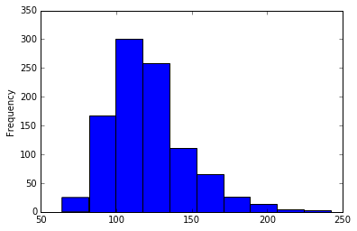

```python
# histogram of the 'duration' Series (shows the distribution of a numerical variable)
movies.duration.plot(kind='hist')
```

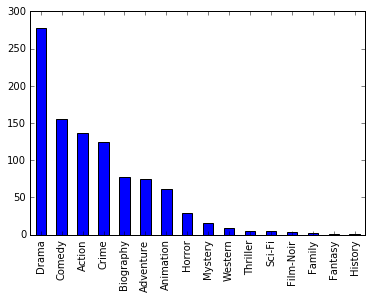

```python
# bar plot of the 'value_counts' for the 'genre' Series
movies.genre.value_counts().plot(kind='bar')
```

Documentation for [**`plot`**](http://pandas.pydata.org/pandas-docs/stable/generated/pandas.Series.plot.html)

[Back to top]

## 16. How do I handle missing values in pandas? ([video](https://www.youtube.com/watch?v=fCMrO_VzeL8&list=PL5-da3qGB5ICCsgW1MxlZ0Hq8LL5U3u9y&index=16))

```python
# read a dataset of UFO reports into a DataFrame
ufo = pd.read_csv('http://bit.ly/uforeports')
ufo.tail()
```

|  | City | Colors Reported | Shape Reported | State | Time |
| --- | --- | --- | --- | --- | --- |
| 18236 | Grant Park | NaN | TRIANGLE | IL | 12/31/2000 23:00 |
| 18237 | Spirit Lake | NaN | DISK | IA | 12/31/2000 23:00 |
| 18238 | Eagle River | NaN | NaN | WI | 12/31/2000 23:45 |
| 18239 | Eagle River | RED | LIGHT | WI | 12/31/2000 23:45 |
| 18240 | Ybor | NaN | OVAL | FL | 12/31/2000 23:59 |

**What does "NaN" mean?**

- "NaN" is not a string, rather it's a special value: **`numpy.nan`**.
- It stands for "Not a Number" and indicates a **missing value**.
- **`read_csv`** detects missing values (by default) when reading the file, and replaces them with this special value.

Documentation for [**`read_csv`**](http://pandas.pydata.org/pandas-docs/stable/generated/pandas.read_csv.html)

```python
# 'isnull' returns a DataFrame of booleans (True if missing, False if not missing)
ufo.isnull().tail()
```

|  | City | Colors Reported | Shape Reported | State | Time |
| --- | --- | --- | --- | --- | --- |
| 18236 | False | True | False | False | False |
| 18237 | False | True | False | False | False |
| 18238 | False | True | True | False | False |
| 18239 | False | False | False | False | False |
| 18240 | False | True | False | False | False |

```python
# 'nonnull' returns the opposite of 'isnull' (True if not missing, False if missing)
ufo.notnull().tail()
```

|  | City | Colors Reported | Shape Reported | State | Time |
| --- | --- | --- | --- | --- | --- |
| 18236 | True | False | True | True | True |
| 18237 | True | False | True | True | True |
| 18238 | True | False | False | True | True |
| 18239 | True | True | True | True | True |
| 18240 | True | False | True | True | True |

Documentation for [**`isnull`**](http://pandas.pydata.org/pandas-docs/stable/generated/pandas.DataFrame.isnull.html) and [**`notnull`**](http://pandas.pydata.org/pandas-docs/stable/generated/pandas.notnull.html)

```python
# count the number of missing values in each Series
ufo.isnull().sum()
```

```
City                  25
Colors Reported    15359
Shape Reported      2644
State                  0
Time                   0
dtype: int64
```

This calculation works because:

1. The **`sum`** method for a DataFrame operates on **`axis=0`** by default (and thus produces column sums).
2. In order to add boolean values, pandas converts **`True`** to **1** and **`False`** to **0**.

```python
# use the 'isnull' Series method to filter the DataFrame rows
ufo[ufo.City.isnull()].head()
```

|  | City | Colors Reported | Shape Reported | State | Time |
| --- | --- | --- | --- | --- | --- |
| 21 | NaN | NaN | NaN | LA | 8/15/1943 0:00 |
| 22 | NaN | NaN | LIGHT | LA | 8/15/1943 0:00 |
| 204 | NaN | NaN | DISK | CA | 7/15/1952 12:30 |
| 241 | NaN | BLUE | DISK | MT | 7/4/1953 14:00 |
| 613 | NaN | NaN | DISK | NV | 7/1/1960 12:00 |

**How to handle missing values** depends on the dataset as well as the nature of your analysis. Here are some options:

```python
# examine the number of rows and columns
ufo.shape
```

```
(18241, 5)
```

```python
# if 'any' values are missing in a row, then drop that row
ufo.dropna(how='any').shape
```

```
(2486, 5)
```

Documentation for [**`dropna`**](http://pandas.pydata.org/pandas-docs/stable/generated/pandas.DataFrame.dropna.html)

```python
# 'inplace' parameter for 'dropna' is False by default, thus rows were only dropped temporarily
ufo.shape
```

```
(18241, 5)
```

```python
# if 'all' values are missing in a row, then drop that row (none are dropped in this case)
ufo.dropna(how='all').shape
```

```
(18241, 5)
```

```python
# if 'any' values are missing in a row (considering only 'City' and 'Shape Reported'), then drop that row
ufo.dropna(subset=['City', 'Shape Reported'], how='any').shape
```

```
(15576, 5)
```

```python
# if 'all' values are missing in a row (considering only 'City' and 'Shape Reported'), then drop that row
ufo.dropna(subset=['City', 'Shape Reported'], how='all').shape
```

```
(18237, 5)
```

```python
# 'value_counts' does not include missing values by default
ufo['Shape Reported'].value_counts().head()
```

```
LIGHT       2803
DISK        2122
TRIANGLE    1889
OTHER       1402
CIRCLE      1365
Name: Shape Reported, dtype: int64
```

```python
# explicitly include missing values
ufo['Shape Reported'].value_counts(dropna=False).head()
```

```
LIGHT       2803
NaN         2644
DISK        2122
TRIANGLE    1889
OTHER       1402
Name: Shape Reported, dtype: int64
```

Documentation for [**`value_counts`**](http://pandas.pydata.org/pandas-docs/stable/generated/pandas.Series.value_counts.html)

```python
# fill in missing values with a specified value
ufo['Shape Reported'].fillna(value='VARIOUS', inplace=True)
```

Documentation for [**`fillna`**](http://pandas.pydata.org/pandas-docs/stable/generated/pandas.DataFrame.fillna.html)

```python
# confirm that the missing values were filled in
ufo['Shape Reported'].value_counts().head()
```

```
VARIOUS     2977
LIGHT       2803
DISK        2122
TRIANGLE    1889
OTHER       1402
Name: Shape Reported, dtype: int64
```

[Working with missing data in pandas](http://pandas.pydata.org/pandas-docs/stable/missing_data.html)

[Back to top]

## 17. What do I need to know about the pandas index? (Part 1) ([video](https://www.youtube.com/watch?v=OYZNk7Z9s6I&list=PL5-da3qGB5ICCsgW1MxlZ0Hq8LL5U3u9y&index=17))

```python
# read a dataset of alcohol consumption into a DataFrame
drinks = pd.read_csv('http://bit.ly/drinksbycountry')
drinks.head()
```

|  | country | beer_servings | spirit_servings | wine_servings | total_litres_of_pure_alcohol | continent |
| --- | --- | --- | --- | --- | --- | --- |
| 0 | Afghanistan | 0 | 0 | 0 | 0.0 | Asia |
| 1 | Albania | 89 | 132 | 54 | 4.9 | Europe |
| 2 | Algeria | 25 | 0 | 14 | 0.7 | Africa |
| 3 | Andorra | 245 | 138 | 312 | 12.4 | Europe |
| 4 | Angola | 217 | 57 | 45 | 5.9 | Africa |

```python
# every DataFrame has an index (sometimes called the "row labels")
drinks.index
```

```
RangeIndex(start=0, stop=193, step=1)
```

```python
# column names are also stored in a special "index" object
drinks.columns
```

```
Index([u'country', u'beer_servings', u'spirit_servings', u'wine_servings',
       u'total_litres_of_pure_alcohol', u'continent'],
      dtype='object')
```

```python
# neither the index nor the columns are included in the shape
drinks.shape
```

```
(193, 6)
```

```python
# index and columns both default to integers if you don't define them
pd.read_table('http://bit.ly/movieusers', header=None, sep='|').head()
```

|  | 0 | 1 | 2 | 3 | 4 |
| --- | --- | --- | --- | --- | --- |
| 0 | 1 | 24 | M | technician | 85711 |
| 1 | 2 | 53 | F | other | 94043 |
| 2 | 3 | 23 | M | writer | 32067 |
| 3 | 4 | 24 | M | technician | 43537 |
| 4 | 5 | 33 | F | other | 15213 |

**What is the index used for?**

1. identification
2. selection
3. alignment (covered in the next video)

```python
# identification: index remains with each row when filtering the DataFrame
drinks[drinks.continent=='South America']
```

|  | country | beer_servings | spirit_servings | wine_servings | total_litres_of_pure_alcohol | continent |
| --- | --- | --- | --- | --- | --- | --- |
| 6 | Argentina | 193 | 25 | 221 | 8.3 | South America |
| 20 | Bolivia | 167 | 41 | 8 | 3.8 | South America |
| 23 | Brazil | 245 | 145 | 16 | 7.2 | South America |
| 35 | Chile | 130 | 124 | 172 | 7.6 | South America |
| 37 | Colombia | 159 | 76 | 3 | 4.2 | South America |
| 52 | Ecuador | 162 | 74 | 3 | 4.2 | South America |
| 72 | Guyana | 93 | 302 | 1 | 7.1 | South America |
| 132 | Paraguay | 213 | 117 | 74 | 7.3 | South America |
| 133 | Peru | 163 | 160 | 21 | 6.1 | South America |
| 163 | Suriname | 128 | 178 | 7 | 5.6 | South America |
| 185 | Uruguay | 115 | 35 | 220 | 6.6 | South America |
| 188 | Venezuela | 333 | 100 | 3 | 7.7 | South America |

```python
# selection: select a portion of the DataFrame using the index
drinks.loc[23, 'beer_servings']
```

```
245
```

Documentation for [**`loc`**](http://pandas.pydata.org/pandas-docs/stable/generated/pandas.DataFrame.loc.html)

```python
# set an existing column as the index
drinks.set_index('country', inplace=True)
drinks.head()
```

| country | beer_servings | spirit_servings | wine_servings | total_litres_of_pure_alcohol | continent |
| --- | --- | --- | --- | --- | --- |
| Afghanistan | 0 | 0 | 0 | 0.0 | Asia |
| Albania | 89 | 132 | 54 | 4.9 | Europe |
| Algeria | 25 | 0 | 14 | 0.7 | Africa |
| Andorra | 245 | 138 | 312 | 12.4 | Europe |
| Angola | 217 | 57 | 45 | 5.9 | Africa |

Documentation for [**`set_index`**](http://pandas.pydata.org/pandas-docs/stable/generated/pandas.DataFrame.set_index.html)

```python
# 'country' is now the index
drinks.index
```

```
Index([u'Afghanistan', u'Albania', u'Algeria', u'Andorra', u'Angola',
       u'Antigua & Barbuda', u'Argentina', u'Armenia', u'Australia',
       u'Austria',
       ...
       u'Tanzania', u'USA', u'Uruguay', u'Uzbekistan', u'Vanuatu',
       u'Venezuela', u'Vietnam', u'Yemen', u'Zambia', u'Zimbabwe'],
      dtype='object', name=u'country', length=193)
```

```python
# 'country' is no longer a column
drinks.columns
```

```
Index([u'beer_servings', u'spirit_servings', u'wine_servings',
       u'total_litres_of_pure_alcohol', u'continent'],
      dtype='object')
```

```python
# 'country' data is no longer part of the DataFrame contents
drinks.shape
```

```
(193, 5)
```

```python
# country name can now be used for selection
drinks.loc['Brazil', 'beer_servings']
```

```
245
```

```python
# index name is optional
drinks.index.name = None
drinks.head()
```

|  | beer_servings | spirit_servings | wine_servings | total_litres_of_pure_alcohol | continent |
| --- | --- | --- | --- | --- | --- |
| Afghanistan | 0 | 0 | 0 | 0.0 | Asia |
| Albania | 89 | 132 | 54 | 4.9 | Europe |
| Algeria | 25 | 0 | 14 | 0.7 | Africa |
| Andorra | 245 | 138 | 312 | 12.4 | Europe |
| Angola | 217 | 57 | 45 | 5.9 | Africa |

```python
# restore the index name, and move the index back to a column
drinks.index.name = 'country'
drinks.reset_index(inplace=True)
drinks.head()
```

|  | country | beer_servings | spirit_servings | wine_servings | total_litres_of_pure_alcohol | continent |
| --- | --- | --- | --- | --- | --- | --- |
| 0 | Afghanistan | 0 | 0 | 0 | 0.0 | Asia |
| 1 | Albania | 89 | 132 | 54 | 4.9 | Europe |
| 2 | Algeria | 25 | 0 | 14 | 0.7 | Africa |
| 3 | Andorra | 245 | 138 | 312 | 12.4 | Europe |
| 4 | Angola | 217 | 57 | 45 | 5.9 | Africa |

Documentation for [**`reset_index`**](http://pandas.pydata.org/pandas-docs/stable/generated/pandas.DataFrame.reset_index.html)

```python
# many DataFrame methods output a DataFrame
drinks.describe()
```

|  | beer_servings | spirit_servings | wine_servings | total_litres_of_pure_alcohol |
| --- | --- | --- | --- | --- |
| count | 193.000000 | 193.000000 | 193.000000 | 193.000000 |
| mean | 106.160622 | 80.994819 | 49.450777 | 4.717098 |
| std | 101.143103 | 88.284312 | 79.697598 | 3.773298 |
| min | 0.000000 | 0.000000 | 0.000000 | 0.000000 |
| 25% | 20.000000 | 4.000000 | 1.000000 | 1.300000 |
| 50% | 76.000000 | 56.000000 | 8.000000 | 4.200000 |
| 75% | 188.000000 | 128.000000 | 59.000000 | 7.200000 |
| max | 376.000000 | 438.000000 | 370.000000 | 14.400000 |

```python
# you can interact with any DataFrame using its index and columns
drinks.describe().loc['25%', 'beer_servings']
```

```
20.0
```

[Indexing and selecting data](http://pandas.pydata.org/pandas-docs/stable/indexing.html)

[Back to top]

## 18. What do I need to know about the pandas index? (Part 2) ([video](https://www.youtube.com/watch?v=15q-is8P_H4&list=PL5-da3qGB5ICCsgW1MxlZ0Hq8LL5U3u9y&index=18))

```python
# read a dataset of alcohol consumption into a DataFrame
drinks = pd.read_csv('http://bit.ly/drinksbycountry')
drinks.head()
```

|  | country | beer_servings | spirit_servings | wine_servings | total_litres_of_pure_alcohol | continent |
| --- | --- | --- | --- | --- | --- | --- |
| 0 | Afghanistan | 0 | 0 | 0 | 0.0 | Asia |
| 1 | Albania | 89 | 132 | 54 | 4.9 | Europe |
| 2 | Algeria | 25 | 0 | 14 | 0.7 | Africa |
| 3 | Andorra | 245 | 138 | 312 | 12.4 | Europe |
| 4 | Angola | 217 | 57 | 45 | 5.9 | Africa |

```python
# every DataFrame has an index
drinks.index
```

```
RangeIndex(start=0, stop=193, step=1)
```

```python
# every Series also has an index (which carries over from the DataFrame)
drinks.continent.head()
```

```
0      Asia
1    Europe
2    Africa
3    Europe
4    Africa
Name: continent, dtype: object
```

```python
# set 'country' as the index
drinks.set_index('country', inplace=True)
```

Documentation for [**`set_index`**](http://pandas.pydata.org/pandas-docs/stable/generated/pandas.DataFrame.set_index.html)

```python
# Series index is on the left, values are on the right
drinks.continent.head()
```

```
country
Afghanistan      Asia
Albania        Europe
Algeria        Africa
Andorra        Europe
Angola         Africa
Name: continent, dtype: object
```

```python
# another example of a Series (output from the 'value_counts' method)
drinks.continent.value_counts()
```

```
Africa           53
Europe           45
Asia             44
North America    23
Oceania          16
South America    12
Name: continent, dtype: int64
```

Documentation for [**`value_counts`**](http://pandas.pydata.org/pandas-docs/stable/generated/pandas.Series.value_counts.html)

```python
# access the Series index
drinks.continent.value_counts().index
```

```
Index([u'Africa', u'Europe', u'Asia', u'North America', u'Oceania',
       u'South America'],
      dtype='object')
```

```python
# access the Series values
drinks.continent.value_counts().values
```

```
array([53, 45, 44, 23, 16, 12], dtype=int64)
```

```python
# elements in a Series can be selected by index (using bracket notation)
drinks.continent.value_counts()['Africa']
```

```
53
```

```python
# any Series can be sorted by its values
drinks.continent.value_counts().sort_values()
```

```
South America    12
Oceania          16
North America    23
Asia             44
Europe           45
Africa           53
Name: continent, dtype: int64
```

```python
# any Series can also be sorted by its index
drinks.continent.value_counts().sort_index()
```

```
Africa           53
Asia             44
Europe           45
North America    23
Oceania          16
South America    12
Name: continent, dtype: int64
```

Documentation for [**`sort_values`**](http://pandas.pydata.org/pandas-docs/stable/generated/pandas.Series.sort_values.html) and [**`sort_index`**](http://pandas.pydata.org/pandas-docs/stable/generated/pandas.Series.sort_index.html)

**What is the index used for?**

1. identification (covered in the previous video)
2. selection (covered in the previous video)
3. alignment

```python
# 'beer_servings' Series contains the average annual beer servings per person
drinks.beer_servings.head()
```

```
country
Afghanistan      0
Albania         89
Algeria         25
Andorra        245
Angola         217
Name: beer_servings, dtype: int64
```

```python
# create a Series containing the population of two countries
people = pd.Series([3000000, 85000], index=['Albania', 'Andorra'], name='population')
people
```

```
Albania    3000000
Andorra      85000
Name: population, dtype: int64
```

Documentation for [**`Series`**](http://pandas.pydata.org/pandas-docs/stable/generated/pandas.Series.html)

```python
# calculate the total annual beer servings for each country
(drinks.beer_servings * people).head()
```

```
Afghanistan            NaN
Albania        267000000.0
Algeria                NaN
Andorra         20825000.0
Angola                 NaN
dtype: float64
```

- The two Series were **aligned** by their indexes.
- If a value is missing in either Series, the result is marked as **NaN**.
- Alignment enables us to easily work with **incomplete data**.

```python
# concatenate the 'drinks' DataFrame with the 'population' Series (aligns by the index)
pd.concat([drinks, people], axis=1).head()
```

|  | beer_servings | spirit_servings | wine_servings | total_litres_of_pure_alcohol | continent | population |
| --- | --- | --- | --- | --- | --- | --- |
| Afghanistan | 0 | 0 | 0 | 0.0 | Asia | NaN |
| Albania | 89 | 132 | 54 | 4.9 | Europe | 3000000.0 |
| Algeria | 25 | 0 | 14 | 0.7 | Africa | NaN |
| Andorra | 245 | 138 | 312 | 12.4 | Europe | 85000.0 |
| Angola | 217 | 57 | 45 | 5.9 | Africa | NaN |

Documentation for [**`concat`**](http://pandas.pydata.org/pandas-docs/stable/generated/pandas.concat.html)

[Indexing and selecting data](http://pandas.pydata.org/pandas-docs/stable/indexing.html)

[Back to top]

## 19. How do I select multiple rows and columns from a pandas DataFrame? ([video](https://www.youtube.com/watch?v=xvpNA7bC8cs&list=PL5-da3qGB5ICCsgW1MxlZ0Hq8LL5U3u9y&index=19))

```python
# read a dataset of UFO reports into a DataFrame
ufo = pd.read_csv('http://bit.ly/uforeports')
ufo.head(3)
```

|  | City | Colors Reported | Shape Reported | State | Time |
| --- | --- | --- | --- | --- | --- |
| 0 | Ithaca | NaN | TRIANGLE | NY | 6/1/1930 22:00 |
| 1 | Willingboro | NaN | OTHER | NJ | 6/30/1930 20:00 |
| 2 | Holyoke | NaN | OVAL | CO | 2/15/1931 14:00 |

The [**`loc`**](http://pandas.pydata.org/pandas-docs/stable/generated/pandas.DataFrame.loc.html) method is used to select rows and columns by **label**. You can pass it:

- A single label
- A list of labels
- A slice of labels
- A boolean Series
- A colon (which indicates "all labels")

```python
# row 0, all columns
ufo.loc[0, :]
```

```
City                       Ithaca
Colors Reported               NaN
Shape Reported           TRIANGLE
State                          NY
Time               6/1/1930 22:00
Name: 0, dtype: object
```

```python
# rows 0 and 1 and 2, all columns
ufo.loc[[0, 1, 2], :]
```

|  | City | Colors Reported | Shape Reported | State | Time |
| --- | --- | --- | --- | --- | --- |
| 0 | Ithaca | NaN | TRIANGLE | NY | 6/1/1930 22:00 |
| 1 | Willingboro | NaN | OTHER | NJ | 6/30/1930 20:00 |
| 2 | Holyoke | NaN | OVAL | CO | 2/15/1931 14:00 |

```python
# rows 0 through 2 (inclusive), all columns
ufo.loc[0:2, :]
```

|  | City | Colors Reported | Shape Reported | State | Time |
| --- | --- | --- | --- | --- | --- |
| 0 | Ithaca | NaN | TRIANGLE | NY | 6/1/1930 22:00 |
| 1 | Willingboro | NaN | OTHER | NJ | 6/30/1930 20:00 |
| 2 | Holyoke | NaN | OVAL | CO | 2/15/1931 14:00 |

```python
# this implies "all columns", but explicitly stating "all columns" is better
ufo.loc[0:2]
```

|  | City | Colors Reported | Shape Reported | State | Time |
| --- | --- | --- | --- | --- | --- |
| 0 | Ithaca | NaN | TRIANGLE | NY | 6/1/1930 22:00 |
| 1 | Willingboro | NaN | OTHER | NJ | 6/30/1930 20:00 |
| 2 | Holyoke | NaN | OVAL | CO | 2/15/1931 14:00 |

```python
# rows 0 through 2 (inclusive), column 'City'
ufo.loc[0:2, 'City']
```

```
0         Ithaca
1    Willingboro
2        Holyoke
Name: City, dtype: object
```

```python
# rows 0 through 2 (inclusive), columns 'City' and 'State'
ufo.loc[0:2, ['City', 'State']]
```

|  | City | State |
| --- | --- | --- |
| 0 | Ithaca | NY |
| 1 | Willingboro | NJ |
| 2 | Holyoke | CO |

```python
# accomplish the same thing using double brackets - but using 'loc' is preferred since it's more explicit
ufo[['City', 'State']].head(3)
```

|  | City | State |
| --- | --- | --- |
| 0 | Ithaca | NY |
| 1 | Willingboro | NJ |
| 2 | Holyoke | CO |

```python
# rows 0 through 2 (inclusive), columns 'City' through 'State' (inclusive)
ufo.loc[0:2, 'City':'State']
```

|  | City | Colors Reported | Shape Reported | State |
| --- | --- | --- | --- | --- |
| 0 | Ithaca | NaN | TRIANGLE | NY |
| 1 | Willingboro | NaN | OTHER | NJ |
| 2 | Holyoke | NaN | OVAL | CO |

```python
# accomplish the same thing using 'head' and 'drop'
ufo.head(3).drop('Time', axis=1)
```

|  | City | Colors Reported | Shape Reported | State |
| --- | --- | --- | --- | --- |
| 0 | Ithaca | NaN | TRIANGLE | NY |
| 1 | Willingboro | NaN | OTHER | NJ |
| 2 | Holyoke | NaN | OVAL | CO |

```python
# rows in which the 'City' is 'Oakland', column 'State'
ufo.loc[ufo.City=='Oakland', 'State']
```

```
1694     CA
2144     CA
4686     MD
7293     CA
8488     CA
8768     CA
10816    OR
10948    CA
11045    CA
12322    CA
12941    CA
16803    MD
17322    CA
Name: State, dtype: object
```

```python
# accomplish the same thing using "chained indexing" - but using 'loc' is preferred since chained indexing can cause problems
ufo[ufo.City=='Oakland'].State
```

```
1694     CA
2144     CA
4686     MD
7293     CA
8488     CA
8768     CA
10816    OR
10948    CA
11045    CA
12322    CA
12941    CA
16803    MD
17322    CA
Name: State, dtype: object
```

The [**`iloc`**](http://pandas.pydata.org/pandas-docs/stable/generated/pandas.DataFrame.iloc.html) method is used to select rows and columns by **integer position**. You can pass it:

- A single integer position
- A list of integer positions
- A slice of integer positions
- A colon (which indicates "all integer positions")

```python
# rows in positions 0 and 1, columns in positions 0 and 3
ufo.iloc[[0, 1], [0, 3]]
```

|  | City | State |
| --- | --- | --- |
| 0 | Ithaca | NY |
| 1 | Willingboro | NJ |

```python
# rows in positions 0 through 2 (exclusive), columns in positions 0 through 4 (exclusive)
ufo.iloc[0:2, 0:4]
```

|  | City | Colors Reported | Shape Reported | State |
| --- | --- | --- | --- | --- |
| 0 | Ithaca | NaN | TRIANGLE | NY |
| 1 | Willingboro | NaN | OTHER | NJ |

```python
# rows in positions 0 through 2 (exclusive), all columns
ufo.iloc[0:2, :]
```

|  | City | Colors Reported | Shape Reported | State | Time |
| --- | --- | --- | --- | --- | --- |
| 0 | Ithaca | NaN | TRIANGLE | NY | 6/1/1930 22:00 |
| 1 | Willingboro | NaN | OTHER | NJ | 6/30/1930 20:00 |

```python
# accomplish the same thing - but using 'iloc' is preferred since it's more explicit
ufo[0:2]
```

|  | City | Colors Reported | Shape Reported | State | Time |
| --- | --- | --- | --- | --- | --- |
| 0 | Ithaca | NaN | TRIANGLE | NY | 6/1/1930 22:00 |
| 1 | Willingboro | NaN | OTHER | NJ | 6/30/1930 20:00 |

The [**`ix`**](http://pandas.pydata.org/pandas-docs/stable/generated/pandas.DataFrame.ix.html) method is used to select rows and columns by **label or integer position**, and should only be used when you need to mix label-based and integer-based selection in the same call.

```python
# read a dataset of alcohol consumption into a DataFrame and set 'country' as the index
drinks = pd.read_csv('http://bit.ly/drinksbycountry', index_col='country')
drinks.head()
```

| country | beer_servings | spirit_servings | wine_servings | total_litres_of_pure_alcohol | continent |
| --- | --- | --- | --- | --- | --- |
| Afghanistan | 0 | 0 | 0 | 0.0 | Asia |
| Albania | 89 | 132 | 54 | 4.9 | Europe |
| Algeria | 25 | 0 | 14 | 0.7 | Africa |
| Andorra | 245 | 138 | 312 | 12.4 | Europe |
| Angola | 217 | 57 | 45 | 5.9 | Africa |

```python
# row with label 'Albania', column in position 0
drinks.ix['Albania', 0]
```

```
89
```

```python
# row in position 1, column with label 'beer_servings'
drinks.ix[1, 'beer_servings']
```

```
89
```

**Rules for using numbers with `ix`:**

- If the index is **strings**, numbers are treated as **integer positions**, and thus slices are **exclusive** on the right.
- If the index is **integers**, numbers are treated as **labels**, and thus slices are **inclusive**.

```python
# rows 'Albania' through 'Andorra' (inclusive), columns in positions 0 through 2 (exclusive)
drinks.ix['Albania':'Andorra', 0:2]
```

| country | beer_servings | spirit_servings |
| --- | --- | --- |
| Albania | 89 | 132 |
| Algeria | 25 | 0 |
| Andorra | 245 | 138 |

```python
# rows 0 through 2 (inclusive), columns in positions 0 through 2 (exclusive)
ufo.ix[0:2, 0:2]
```

|  | City | Colors Reported |
| --- | --- | --- |
| 0 | Ithaca | NaN |
| 1 | Willingboro | NaN |
| 2 | Holyoke | NaN |

[Summary of the pandas API for selection](https://github.com/pydata/pandas/issues/9595)

[Back to top]

## 20. When should I use the "inplace" parameter in pandas? ([video](https://www.youtube.com/watch?v=XaCSdr7pPmY&list=PL5-da3qGB5ICCsgW1MxlZ0Hq8LL5U3u9y&index=20))

```python
# read a dataset of UFO reports into a DataFrame
ufo = pd.read_csv('http://bit.ly/uforeports')
ufo.head()
```

|  | City | Colors Reported | Shape Reported | State | Time |
| --- | --- | --- | --- | --- | --- |
| 0 | Ithaca | NaN | TRIANGLE | NY | 6/1/1930 22:00 |
| 1 | Willingboro | NaN | OTHER | NJ | 6/30/1930 20:00 |
| 2 | Holyoke | NaN | OVAL | CO | 2/15/1931 14:00 |
| 3 | Abilene | NaN | DISK | KS | 6/1/1931 13:00 |
| 4 | New York Worlds Fair | NaN | LIGHT | NY | 4/18/1933 19:00 |

```python
ufo.shape
```

```
(18241, 5)
```

```python
# remove the 'City' column (doesn't affect the DataFrame since inplace=False)
ufo.drop('City', axis=1).head()
```

|  | Colors Reported | Shape Reported | State | Time |
| --- | --- | --- | --- | --- |
| 0 | NaN | TRIANGLE | NY | 6/1/1930 22:00 |
| 1 | NaN | OTHER | NJ | 6/30/1930 20:00 |
| 2 | NaN | OVAL | CO | 2/15/1931 14:00 |
| 3 | NaN | DISK | KS | 6/1/1931 13:00 |
| 4 | NaN | LIGHT | NY | 4/18/1933 19:00 |

```python
# confirm that the 'City' column was not actually removed
ufo.head()
```

|  | City | Colors Reported | Shape Reported | State | Time |
| --- | --- | --- | --- | --- | --- |
| 0 | Ithaca | NaN | TRIANGLE | NY | 6/1/1930 22:00 |
| 1 | Willingboro | NaN | OTHER | NJ | 6/30/1930 20:00 |
| 2 | Holyoke | NaN | OVAL | CO | 2/15/1931 14:00 |
| 3 | Abilene | NaN | DISK | KS | 6/1/1931 13:00 |
| 4 | New York Worlds Fair | NaN | LIGHT | NY | 4/18/1933 19:00 |

```python
# remove the 'City' column (does affect the DataFrame since inplace=True)
ufo.drop('City', axis=1, inplace=True)
```

```python
# confirm that the 'City' column was actually removed
ufo.head()
```

|  | Colors Reported | Shape Reported | State | Time |
| --- | --- | --- | --- | --- |
| 0 | NaN | TRIANGLE | NY | 6/1/1930 22:00 |
| 1 | NaN | OTHER | NJ | 6/30/1930 20:00 |
| 2 | NaN | OVAL | CO | 2/15/1931 14:00 |
| 3 | NaN | DISK | KS | 6/1/1931 13:00 |
| 4 | NaN | LIGHT | NY | 4/18/1933 19:00 |

```python
# drop a row if any value is missing from that row (doesn't affect the DataFrame since inplace=False)
ufo.dropna(how='any').shape
```

```
(2490, 4)
```

```python
# confirm that no rows were actually removed
ufo.shape
```

```
(18241, 4)
```

```python
# use an assignment statement instead of the 'inplace' parameter
ufo = ufo.set_index('Time')
ufo.tail()
```

| Time | Colors Reported | Shape Reported | State |
| --- | --- | --- | --- |
| 12/31/2000 23:00 | NaN | TRIANGLE | IL |
| 12/31/2000 23:00 | NaN | DISK | IA |
| 12/31/2000 23:45 | NaN | NaN | WI |
| 12/31/2000 23:45 | RED | LIGHT | WI |
| 12/31/2000 23:59 | NaN | OVAL | FL |

```python
# fill missing values using "backward fill" strategy (doesn't affect the DataFrame since inplace=False)
ufo.fillna(method='bfill').tail()
```

| Time | Colors Reported | Shape Reported | State |
| --- | --- | --- | --- |
| 12/31/2000 23:00 | RED | TRIANGLE | IL |
| 12/31/2000 23:00 | RED | DISK | IA |
| 12/31/2000 23:45 | RED | LIGHT | WI |
| 12/31/2000 23:45 | RED | LIGHT | WI |
| 12/31/2000 23:59 | NaN | OVAL | FL |

```python
# compare with "forward fill" strategy (doesn't affect the DataFrame since inplace=False)
ufo.fillna(method='ffill').tail()
```

| Time | Colors Reported | Shape Reported | State |
| --- | --- | --- | --- |
| 12/31/2000 23:00 | RED | TRIANGLE | IL |
| 12/31/2000 23:00 | RED | DISK | IA |
| 12/31/2000 23:45 | RED | DISK | WI |
| 12/31/2000 23:45 | RED | LIGHT | WI |
| 12/31/2000 23:59 | RED | OVAL | FL |

[Back to top]

## 21. How do I make my pandas DataFrame smaller and faster? ([video](https://www.youtube.com/watch?v=wDYDYGyN_cw&list=PL5-da3qGB5ICCsgW1MxlZ0Hq8LL5U3u9y&index=21))

```python
# read a dataset of alcohol consumption into a DataFrame
drinks = pd.read_csv('http://bit.ly/drinksbycountry')
drinks.head()
```

|  | country | beer_servings | spirit_servings | wine_servings | total_litres_of_pure_alcohol | continent |
| --- | --- | --- | --- | --- | --- | --- |
| 0 | Afghanistan | 0 | 0 | 0 | 0.0 | Asia |
| 1 | Albania | 89 | 132 | 54 | 4.9 | Europe |
| 2 | Algeria | 25 | 0 | 14 | 0.7 | Africa |
| 3 | Andorra | 245 | 138 | 312 | 12.4 | Europe |
| 4 | Angola | 217 | 57 | 45 | 5.9 | Africa |

```python
# exact memory usage is unknown because object columns are references elsewhere
drinks.info()
```

```
<class 'pandas.core.frame.DataFrame'>
RangeIndex: 193 entries, 0 to 192
Data columns (total 6 columns):
country                         193 non-null object
beer_servings                   193 non-null int64
spirit_servings                 193 non-null int64
wine_servings                   193 non-null int64
total_litres_of_pure_alcohol    193 non-null float64
continent                       193 non-null object
dtypes: float64(1), int64(3), object(2)
memory usage: 9.1+ KB
```

```python
# force pandas to calculate the true memory usage
drinks.info(memory_usage='deep')
```

```
<class 'pandas.core.frame.DataFrame'>
RangeIndex: 193 entries, 0 to 192
Data columns (total 6 columns):
country                         193 non-null object
beer_servings                   193 non-null int64
spirit_servings                 193 non-null int64
wine_servings                   193 non-null int64
total_litres_of_pure_alcohol    193 non-null float64
continent                       193 non-null object
dtypes: float64(1), int64(3), object(2)
memory usage: 24.4 KB
```

```python
# calculate the memory usage for each Series (in bytes)
drinks.memory_usage(deep=True)
```

```
Index                             72
country                         9500
beer_servings                   1544
spirit_servings                 1544
wine_servings                   1544
total_litres_of_pure_alcohol    1544
continent                       9244
dtype: int64
```

Documentation for [**`info`**](http://pandas.pydata.org/pandas-docs/stable/generated/pandas.DataFrame.info.html) and [**`memory_usage`**](http://pandas.pydata.org/pandas-docs/stable/generated/pandas.DataFrame.memory_usage.html)

```python
# use the 'category' data type (new in pandas 0.15) to store the 'continent' strings as integers
drinks['continent'] = drinks.continent.astype('category')
drinks.dtypes
```

```
country                           object
beer_servings                      int64
spirit_servings                    int64
wine_servings                      int64
total_litres_of_pure_alcohol     float64
continent                       category
dtype: object
```

```python
# 'continent' Series appears to be unchanged
drinks.continent.head()
```

```
0      Asia
1    Europe
2    Africa
3    Europe
4    Africa
Name: continent, dtype: category
Categories (6, object): [Africa, Asia, Europe, North America, Oceania, South America]
```

```python
# strings are now encoded (0 means 'Africa', 1 means 'Asia', 2 means 'Europe', etc.)
drinks.continent.cat.codes.head()
```

```
0    1
1    2
2    0
3    2
4    0
dtype: int8
```

```python
# memory usage has been drastically reduced
drinks.memory_usage(deep=True)
```

```
Index                             72
country                         9500
beer_servings                   1544
spirit_servings                 1544
wine_servings                   1544
total_litres_of_pure_alcohol    1544
continent                        488
dtype: int64
```

```python
# repeat this process for the 'country' Series
drinks['country'] = drinks.country.astype('category')
drinks.memory_usage(deep=True)
```

```
Index                             72
country                         9886
beer_servings                   1544
spirit_servings                 1544
wine_servings                   1544
total_litres_of_pure_alcohol    1544
continent                        488
dtype: int64
```

```python
# memory usage increased because we created 193 categories
drinks.country.cat.categories
```

```
Index([u'Afghanistan', u'Albania', u'Algeria', u'Andorra', u'Angola',
       u'Antigua & Barbuda', u'Argentina', u'Armenia', u'Australia',
       u'Austria',
       ...
       u'United Arab Emirates', u'United Kingdom', u'Uruguay', u'Uzbekistan',
       u'Vanuatu', u'Venezuela', u'Vietnam', u'Yemen', u'Zambia', u'Zimbabwe'],
      dtype='object', length=193)
```

The **category** data type should only be used with a string Series that has a **small number of possible values**.

```python
# create a small DataFrame from a dictionary
df = pd.DataFrame({'ID':[100, 101, 102, 103], 'quality':['good', 'very good', 'good', 'excellent']})
df
```

|  | ID | quality |
| --- | --- | --- |
| 0 | 100 | good |
| 1 | 101 | very good |
| 2 | 102 | good |
| 3 | 103 | excellent |

```python
# sort the DataFrame by the 'quality' Series (alphabetical order)
df.sort_values('quality')
```

|  | ID | quality |
| --- | --- | --- |
| 3 | 103 | excellent |
| 0 | 100 | good |
| 2 | 102 | good |
| 1 | 101 | very good |

```python
# define a logical ordering for the categories
df['quality'] = df.quality.astype('category', categories=['good', 'very good', 'excellent'], ordered=True)
df.quality
```

```
0         good
1    very good
2         good
3    excellent
Name: quality, dtype: category
Categories (3, object): [good < very good < excellent]
```

```python
# sort the DataFrame by the 'quality' Series (logical order)
df.sort_values('quality')
```

|  | ID | quality |
| --- | --- | --- |
| 0 | 100 | good |
| 2 | 102 | good |
| 1 | 101 | very good |
| 3 | 103 | excellent |

```python
# comparison operators work with ordered categories
df.loc[df.quality > 'good', :]
```

|  | ID | quality |
| --- | --- | --- |
| 1 | 101 | very good |
| 3 | 103 | excellent |

[Overview of categorical data in pandas](http://pandas.pydata.org/pandas-docs/stable/categorical.html)

[API reference for categorical methods](http://pandas.pydata.org/pandas-docs/stable/api.html#categorical)

[Back to top]

## 22. How do I use pandas with scikit-learn to create Kaggle submissions? ([video](https://www.youtube.com/watch?v=ylRlGCtAtiE&list=PL5-da3qGB5ICCsgW1MxlZ0Hq8LL5U3u9y&index=22))

```python
# read the training dataset from Kaggle's Titanic competition into a DataFrame
train = pd.read_csv('http://bit.ly/kaggletrain')
train.head()
```

|  | PassengerId | Survived | Pclass | Name | Sex | Age | SibSp | Parch | Ticket | Fare | Cabin | Embarked |
| --- | --- | --- | --- | --- | --- | --- | --- | --- | --- | --- | --- | --- |
| 0 | 1 | 0 | 3 | Braund, Mr. Owen Harris | male | 22.0 | 1 | 0 | A/5 21171 | 7.2500 | NaN | S |
| 1 | 2 | 1 | 1 | Cumings, Mrs. John Bradley (Florence Briggs Th... | female | 38.0 | 1 | 0 | PC 17599 | 71.2833 | C85 | C |
| 2 | 3 | 1 | 3 | Heikkinen, Miss. Laina | female | 26.0 | 0 | 0 | STON/O2. 3101282 | 7.9250 | NaN | S |
| 3 | 4 | 1 | 1 | Futrelle, Mrs. Jacques Heath (Lily May Peel) | female | 35.0 | 1 | 0 | 113803 | 53.1000 | C123 | S |
| 4 | 5 | 0 | 3 | Allen, Mr. William Henry | male | 35.0 | 0 | 0 | 373450 | 8.0500 | NaN | S |

**Goal:** Predict passenger survival aboard the Titanic based on [passenger attributes](https://www.kaggle.com/c/titanic/data)

**Video:** [What is machine learning, and how does it work?](https://www.youtube.com/watch?v=elojMnjn4kk&list=PL5-da3qGB5ICeMbQuqbbCOQWcS6OYBr5A&index=1)

```python
# create a feature matrix 'X' by selecting two DataFrame columns
feature_cols = ['Pclass', 'Parch']
X = train.loc[:, feature_cols]
X.shape
```

```
(891, 2)
```

```python
# create a response vector 'y' by selecting a Series
y = train.Survived
y.shape
```

```
(891L,)
```

**Note:** There is no need to convert these pandas objects to NumPy arrays. scikit-learn will understand these objects as long as they are entirely numeric and the proper shapes.

```python
# fit a classification model to the training data
from sklearn.linear_model import LogisticRegression
logreg = LogisticRegression()
logreg.fit(X, y)
```

```
LogisticRegression(C=1.0, class_weight=None, dual=False, fit_intercept=True,
          intercept_scaling=1, max_iter=100, multi_class='ovr', n_jobs=1,
          penalty='l2', random_state=None, solver='liblinear', tol=0.0001,
          verbose=0, warm_start=False)
```

**Video series:** [Introduction to machine learning with scikit-learn](https://www.youtube.com/playlist?list=PL5-da3qGB5ICeMbQuqbbCOQWcS6OYBr5A)

```python
# read the testing dataset from Kaggle's Titanic competition into a DataFrame
test = pd.read_csv('http://bit.ly/kaggletest')
test.head()
```

|  | PassengerId | Pclass | Name | Sex | Age | SibSp | Parch | Ticket | Fare | Cabin | Embarked |
| --- | --- | --- | --- | --- | --- | --- | --- | --- | --- | --- | --- |
| 0 | 892 | 3 | Kelly, Mr. James | male | 34.5 | 0 | 0 | 330911 | 7.8292 | NaN | Q |
| 1 | 893 | 3 | Wilkes, Mrs. James (Ellen Needs) | female | 47.0 | 1 | 0 | 363272 | 7.0000 | NaN | S |
| 2 | 894 | 2 | Myles, Mr. Thomas Francis | male | 62.0 | 0 | 0 | 240276 | 9.6875 | NaN | Q |
| 3 | 895 | 3 | Wirz, Mr. Albert | male | 27.0 | 0 | 0 | 315154 | 8.6625 | NaN | S |
| 4 | 896 | 3 | Hirvonen, Mrs. Alexander (Helga E Lindqvist) | female | 22.0 | 1 | 1 | 3101298 | 12.2875 | NaN | S |

```python
# create a feature matrix from the testing data that matches the training data
X_new = test.loc[:, feature_cols]
X_new.shape
```

```
(418, 2)
```

```python
# use the fitted model to make predictions for the testing set observations
new_pred_class = logreg.predict(X_new)
```

```python
# create a DataFrame of passenger IDs and testing set predictions
pd.DataFrame({'PassengerId':test.PassengerId, 'Survived':new_pred_class}).head()
```

|  | PassengerId | Survived |
| --- | --- | --- |
| 0 | 892 | 0 |
| 1 | 893 | 0 |
| 2 | 894 | 0 |
| 3 | 895 | 0 |
| 4 | 896 | 0 |

Documentation for the [**`DataFrame`**](http://pandas.pydata.org/pandas-docs/stable/generated/pandas.DataFrame.html) constructor

```python
# ensure that PassengerID is the first column by setting it as the index
pd.DataFrame({'PassengerId':test.PassengerId, 'Survived':new_pred_class}).set_index('PassengerId').head()
```

| PassengerId | Survived |
| --- | --- |
| 892 | 0 |
| 893 | 0 |
| 894 | 0 |
| 895 | 0 |
| 896 | 0 |

```python
# write the DataFrame to a CSV file that can be submitted to Kaggle
pd.DataFrame({'PassengerId':test.PassengerId, 'Survived':new_pred_class}).set_index('PassengerId').to_csv('sub.csv')
```

Documentation for [**`to_csv`**](http://pandas.pydata.org/pandas-docs/stable/generated/pandas.DataFrame.to_csv.html)

```python
# save a DataFrame to disk ("pickle it")
train.to_pickle('train.pkl')
```

```python
# read a pickled object from disk ("unpickle it")
pd.read_pickle('train.pkl').head()
```

|  | PassengerId | Survived | Pclass | Name | Sex | Age | SibSp | Parch | Ticket | Fare | Cabin | Embarked |
| --- | --- | --- | --- | --- | --- | --- | --- | --- | --- | --- | --- | --- |
| 0 | 1 | 0 | 3 | Braund, Mr. Owen Harris | male | 22.0 | 1 | 0 | A/5 21171 | 7.2500 | NaN | S |
| 1 | 2 | 1 | 1 | Cumings, Mrs. John Bradley (Florence Briggs Th... | female | 38.0 | 1 | 0 | PC 17599 | 71.2833 | C85 | C |
| 2 | 3 | 1 | 3 | Heikkinen, Miss. Laina | female | 26.0 | 0 | 0 | STON/O2. 3101282 | 7.9250 | NaN | S |
| 3 | 4 | 1 | 1 | Futrelle, Mrs. Jacques Heath (Lily May Peel) | female | 35.0 | 1 | 0 | 113803 | 53.1000 | C123 | S |
| 4 | 5 | 0 | 3 | Allen, Mr. William Henry | male | 35.0 | 0 | 0 | 373450 | 8.0500 | NaN | S |

Documentation for [**`to_pickle`**](http://pandas.pydata.org/pandas-docs/stable/generated/pandas.DataFrame.to_pickle.html) and [**`read_pickle`**](http://pandas.pydata.org/pandas-docs/stable/generated/pandas.read_pickle.html)

[Back to top]

## 23. More of your pandas questions answered! ([video](https://www.youtube.com/watch?v=oH3wYKvwpJ8&list=PL5-da3qGB5ICCsgW1MxlZ0Hq8LL5U3u9y&index=23))

**Question:** Could you explain how to read the pandas documentation?

[pandas API reference](http://pandas.pydata.org/pandas-docs/stable/api.html)

**Question:** What is the difference between **`ufo.isnull()`** and **`pd.isnull(ufo)`**?

```python
# read a dataset of UFO reports into a DataFrame
ufo = pd.read_csv('http://bit.ly/uforeports')
ufo.head()
```

|  | City | Colors Reported | Shape Reported | State | Time |
| --- | --- | --- | --- | --- | --- |
| 0 | Ithaca | NaN | TRIANGLE | NY | 6/1/1930 22:00 |
| 1 | Willingboro | NaN | OTHER | NJ | 6/30/1930 20:00 |
| 2 | Holyoke | NaN | OVAL | CO | 2/15/1931 14:00 |
| 3 | Abilene | NaN | DISK | KS | 6/1/1931 13:00 |
| 4 | New York Worlds Fair | NaN | LIGHT | NY | 4/18/1933 19:00 |

```python
# use 'isnull' as a top-level function
pd.isnull(ufo).head()
```

|  | City | Colors Reported | Shape Reported | State | Time |
| --- | --- | --- | --- | --- | --- |
| 0 | False | True | False | False | False |
| 1 | False | True | False | False | False |
| 2 | False | True | False | False | False |
| 3 | False | True | False | False | False |
| 4 | False | True | False | False | False |

```python
# equivalent: use 'isnull' as a DataFrame method
ufo.isnull().head()
```

|  | City | Colors Reported | Shape Reported | State | Time |
| --- | --- | --- | --- | --- | --- |
| 0 | False | True | False | False | False |
| 1 | False | True | False | False | False |
| 2 | False | True | False | False | False |
| 3 | False | True | False | False | False |
| 4 | False | True | False | False | False |

Documentation for [**`isnull`**](http://pandas.pydata.org/pandas-docs/stable/generated/pandas.DataFrame.isnull.html)

**Question:** Why are DataFrame slices inclusive when using **`.loc`**, but exclusive when using **`.iloc`**?

```python
# label-based slicing is inclusive of the start and stop
ufo.loc[0:4, :]
```

|  | City | Colors Reported | Shape Reported | State | Time |
| --- | --- | --- | --- | --- | --- |
| 0 | Ithaca | NaN | TRIANGLE | NY | 6/1/1930 22:00 |
| 1 | Willingboro | NaN | OTHER | NJ | 6/30/1930 20:00 |
| 2 | Holyoke | NaN | OVAL | CO | 2/15/1931 14:00 |
| 3 | Abilene | NaN | DISK | KS | 6/1/1931 13:00 |
| 4 | New York Worlds Fair | NaN | LIGHT | NY | 4/18/1933 19:00 |

```python
# position-based slicing is inclusive of the start and exclusive of the stop
ufo.iloc[0:4, :]
```

|  | City | Colors Reported | Shape Reported | State | Time |
| --- | --- | --- | --- | --- | --- |
| 0 | Ithaca | NaN | TRIANGLE | NY | 6/1/1930 22:00 |
| 1 | Willingboro | NaN | OTHER | NJ | 6/30/1930 20:00 |
| 2 | Holyoke | NaN | OVAL | CO | 2/15/1931 14:00 |
| 3 | Abilene | NaN | DISK | KS | 6/1/1931 13:00 |

Documentation for [**`loc`**](http://pandas.pydata.org/pandas-docs/stable/generated/pandas.DataFrame.loc.html) and [**`iloc`**](http://pandas.pydata.org/pandas-docs/stable/generated/pandas.DataFrame.iloc.html)

```python
# 'iloc' is simply following NumPy's slicing convention...
ufo.values[0:4, :]
```

```
array([['Ithaca', nan, 'TRIANGLE', 'NY', '6/1/1930 22:00'],
       ['Willingboro', nan, 'OTHER', 'NJ', '6/30/1930 20:00'],
       ['Holyoke', nan, 'OVAL', 'CO', '2/15/1931 14:00'],
       ['Abilene', nan, 'DISK', 'KS', '6/1/1931 13:00']], dtype=object)
```

```python
# ...and NumPy is simply following Python's slicing convention
'python'[0:4]
```

```
'pyth'
```

```python
# 'loc' is inclusive of the stopping label because you don't necessarily know what label will come after it
ufo.loc[0:4, 'City':'State']
```

|  | City | Colors Reported | Shape Reported | State |
| --- | --- | --- | --- | --- |
| 0 | Ithaca | NaN | TRIANGLE | NY |
| 1 | Willingboro | NaN | OTHER | NJ |
| 2 | Holyoke | NaN | OVAL | CO |
| 3 | Abilene | NaN | DISK | KS |
| 4 | New York Worlds Fair | NaN | LIGHT | NY |

**Question:** How do I randomly sample rows from a DataFrame?

```python
# sample 3 rows from the DataFrame without replacement (new in pandas 0.16.1)
ufo.sample(n=3)
```

|  | City | Colors Reported | Shape Reported | State | Time |
| --- | --- | --- | --- | --- | --- |
| 13722 | Lincoln City | NaN | LIGHT | OR | 6/16/1999 23:00 |
| 14564 | Pagosa Springs | NaN | CIGAR | CO | 9/12/1999 20:55 |
| 4176 | Chicago | NaN | VARIOUS | IL | 8/28/1979 2:45 |

Documentation for [**`sample`**](http://pandas.pydata.org/pandas-docs/stable/generated/pandas.DataFrame.sample.html)

```python
# use the 'random_state' parameter for reproducibility
ufo.sample(n=3, random_state=42)
```

|  | City | Colors Reported | Shape Reported | State | Time |
| --- | --- | --- | --- | --- | --- |
| 217 | Norridgewock | NaN | DISK | ME | 9/15/1952 14:00 |
| 12282 | Ipava | NaN | TRIANGLE | IL | 10/1/1998 21:15 |
| 17933 | Ellinwood | NaN | FIREBALL | KS | 11/13/2000 22:00 |

```python
# sample 75% of the DataFrame's rows without replacement
train = ufo.sample(frac=0.75, random_state=99)
```

```python
# store the remaining 25% of the rows in another DataFrame
test = ufo.loc[~ufo.index.isin(train.index), :]
```

Documentation for [**`isin`**](http://pandas.pydata.org/pandas-docs/stable/generated/pandas.Index.isin.html)

[Back to top]

## 24. How do I create dummy variables in pandas? ([video](https://www.youtube.com/watch?v=0s_1IsROgDc&list=PL5-da3qGB5ICCsgW1MxlZ0Hq8LL5U3u9y&index=24))

```python
# read the training dataset from Kaggle's Titanic competition
train = pd.read_csv('http://bit.ly/kaggletrain')
train.head()
```

|  | PassengerId | Survived | Pclass | Name | Sex | Age | SibSp | Parch | Ticket | Fare | Cabin | Embarked |
| --- | --- | --- | --- | --- | --- | --- | --- | --- | --- | --- | --- | --- |
| 0 | 1 | 0 | 3 | Braund, Mr. Owen Harris | male | 22.0 | 1 | 0 | A/5 21171 | 7.2500 | NaN | S |
| 1 | 2 | 1 | 1 | Cumings, Mrs. John Bradley (Florence Briggs Th... | female | 38.0 | 1 | 0 | PC 17599 | 71.2833 | C85 | C |
| 2 | 3 | 1 | 3 | Heikkinen, Miss. Laina | female | 26.0 | 0 | 0 | STON/O2. 3101282 | 7.9250 | NaN | S |
| 3 | 4 | 1 | 1 | Futrelle, Mrs. Jacques Heath (Lily May Peel) | female | 35.0 | 1 | 0 | 113803 | 53.1000 | C123 | S |
| 4 | 5 | 0 | 3 | Allen, Mr. William Henry | male | 35.0 | 0 | 0 | 373450 | 8.0500 | NaN | S |

```python
# create the 'Sex_male' dummy variable using the 'map' method
train['Sex_male'] = train.Sex.map({'female':0, 'male':1})
train.head()
```

|  | PassengerId | Survived | Pclass | Name | Sex | Age | SibSp | Parch | Ticket | Fare | Cabin | Embarked | Sex_male |
| --- | --- | --- | --- | --- | --- | --- | --- | --- | --- | --- | --- | --- | --- |
| 0 | 1 | 0 | 3 | Braund, Mr. Owen Harris | male | 22.0 | 1 | 0 | A/5 21171 | 7.2500 | NaN | S | 1 |
| 1 | 2 | 1 | 1 | Cumings, Mrs. John Bradley (Florence Briggs Th... | female | 38.0 | 1 | 0 | PC 17599 | 71.2833 | C85 | C | 0 |
| 2 | 3 | 1 | 3 | Heikkinen, Miss. Laina | female | 26.0 | 0 | 0 | STON/O2. 3101282 | 7.9250 | NaN | S | 0 |
| 3 | 4 | 1 | 1 | Futrelle, Mrs. Jacques Heath (Lily May Peel) | female | 35.0 | 1 | 0 | 113803 | 53.1000 | C123 | S | 0 |
| 4 | 5 | 0 | 3 | Allen, Mr. William Henry | male | 35.0 | 0 | 0 | 373450 | 8.0500 | NaN | S | 1 |

Documentation for [**`map`**](http://pandas.pydata.org/pandas-docs/stable/generated/pandas.Series.map.html)

```python
# alternative: use 'get_dummies' to create one column for every possible value
pd.get_dummies(train.Sex).head()
```

|  | female | male |
| --- | --- | --- |
| 0 | 0.0 | 1.0 |
| 1 | 1.0 | 0.0 |
| 2 | 1.0 | 0.0 |
| 3 | 1.0 | 0.0 |
| 4 | 0.0 | 1.0 |

Generally speaking:

- If you have **"K" possible values** for a categorical feature, you only need **"K-1" dummy variables** to capture all of the information about that feature.
- One convention is to **drop the first dummy variable**, which defines that level as the "baseline".

```python
# drop the first dummy variable ('female') using the 'iloc' method
pd.get_dummies(train.Sex).iloc[:, 1:].head()
```

|  | male |
| --- | --- |
| 0 | 1.0 |
| 1 | 0.0 |
| 2 | 0.0 |
| 3 | 0.0 |
| 4 | 1.0 |

```python
# add a prefix to identify the source of the dummy variables
pd.get_dummies(train.Sex, prefix='Sex').iloc[:, 1:].head()
```

|  | Sex_male |
| --- | --- |
| 0 | 1.0 |
| 1 | 0.0 |
| 2 | 0.0 |
| 3 | 0.0 |
| 4 | 1.0 |

```python
# use 'get_dummies' with a feature that has 3 possible values
pd.get_dummies(train.Embarked, prefix='Embarked').head(10)
```

|  | Embarked_C | Embarked_Q | Embarked_S |
| --- | --- | --- | --- |
| 0 | 0.0 | 0.0 | 1.0 |
| 1 | 1.0 | 0.0 | 0.0 |
| 2 | 0.0 | 0.0 | 1.0 |
| 3 | 0.0 | 0.0 | 1.0 |
| 4 | 0.0 | 0.0 | 1.0 |
| 5 | 0.0 | 1.0 | 0.0 |
| 6 | 0.0 | 0.0 | 1.0 |
| 7 | 0.0 | 0.0 | 1.0 |
| 8 | 0.0 | 0.0 | 1.0 |
| 9 | 1.0 | 0.0 | 0.0 |

```python
# drop the first dummy variable ('C')
pd.get_dummies(train.Embarked, prefix='Embarked').iloc[:, 1:].head(10)
```

|  | Embarked_Q | Embarked_S |
| --- | --- | --- |
| 0 | 0.0 | 1.0 |
| 1 | 0.0 | 0.0 |
| 2 | 0.0 | 1.0 |
| 3 | 0.0 | 1.0 |
| 4 | 0.0 | 1.0 |
| 5 | 1.0 | 0.0 |
| 6 | 0.0 | 1.0 |
| 7 | 0.0 | 1.0 |
| 8 | 0.0 | 1.0 |
| 9 | 0.0 | 0.0 |

How to translate these values back to the original 'Embarked' value:

- **0, 0** means **C**
- **1, 0** means **Q**
- **0, 1** means **S**

```python
# save the DataFrame of dummy variables and concatenate them to the original DataFrame
embarked_dummies = pd.get_dummies(train.Embarked, prefix='Embarked').iloc[:, 1:]
train = pd.concat([train, embarked_dummies], axis=1)
train.head()
```

|  | PassengerId | Survived | Pclass | Name | Sex | Age | SibSp | Parch | Ticket | Fare | Cabin | Embarked | Sex_male | Embarked_Q | Embarked_S |
| --- | --- | --- | --- | --- | --- | --- | --- | --- | --- | --- | --- | --- | --- | --- | --- |
| 0 | 1 | 0 | 3 | Braund, Mr. Owen Harris | male | 22.0 | 1 | 0 | A/5 21171 | 7.2500 | NaN | S | 1 | 0.0 | 1.0 |
| 1 | 2 | 1 | 1 | Cumings, Mrs. John Bradley (Florence Briggs Th... | female | 38.0 | 1 | 0 | PC 17599 | 71.2833 | C85 | C | 0 | 0.0 | 0.0 |
| 2 | 3 | 1 | 3 | Heikkinen, Miss. Laina | female | 26.0 | 0 | 0 | STON/O2. 3101282 | 7.9250 | NaN | S | 0 | 0.0 | 1.0 |
| 3 | 4 | 1 | 1 | Futrelle, Mrs. Jacques Heath (Lily May Peel) | female | 35.0 | 1 | 0 | 113803 | 53.1000 | C123 | S | 0 | 0.0 | 1.0 |
| 4 | 5 | 0 | 3 | Allen, Mr. William Henry | male | 35.0 | 0 | 0 | 373450 | 8.0500 | NaN | S | 1 | 0.0 | 1.0 |

Documentation for [**`concat`**](http://pandas.pydata.org/pandas-docs/stable/generated/pandas.concat.html)

```python
# reset the DataFrame
train = pd.read_csv('http://bit.ly/kaggletrain')
train.head()
```

|  | PassengerId | Survived | Pclass | Name | Sex | Age | SibSp | Parch | Ticket | Fare | Cabin | Embarked |
| --- | --- | --- | --- | --- | --- | --- | --- | --- | --- | --- | --- | --- |
| 0 | 1 | 0 | 3 | Braund, Mr. Owen Harris | male | 22.0 | 1 | 0 | A/5 21171 | 7.2500 | NaN | S |
| 1 | 2 | 1 | 1 | Cumings, Mrs. John Bradley (Florence Briggs Th... | female | 38.0 | 1 | 0 | PC 17599 | 71.2833 | C85 | C |
| 2 | 3 | 1 | 3 | Heikkinen, Miss. Laina | female | 26.0 | 0 | 0 | STON/O2. 3101282 | 7.9250 | NaN | S |
| 3 | 4 | 1 | 1 | Futrelle, Mrs. Jacques Heath (Lily May Peel) | female | 35.0 | 1 | 0 | 113803 | 53.1000 | C123 | S |
| 4 | 5 | 0 | 3 | Allen, Mr. William Henry | male | 35.0 | 0 | 0 | 373450 | 8.0500 | NaN | S |

```python
# pass the DataFrame to 'get_dummies' and specify which columns to dummy (it drops the original columns)
pd.get_dummies(train, columns=['Sex', 'Embarked']).head()
```

|  | PassengerId | Survived | Pclass | Name | Age | SibSp | Parch | Ticket | Fare | Cabin | Sex_female | Sex_male | Embarked_C | Embarked_Q | Embarked_S |
| --- | --- | --- | --- | --- | --- | --- | --- | --- | --- | --- | --- | --- | --- | --- | --- |
| 0 | 1 | 0 | 3 | Braund, Mr. Owen Harris | 22.0 | 1 | 0 | A/5 21171 | 7.2500 | NaN | 0.0 | 1.0 | 0.0 | 0.0 | 1.0 |
| 1 | 2 | 1 | 1 | Cumings, Mrs. John Bradley (Florence Briggs Th... | 38.0 | 1 | 0 | PC 17599 | 71.2833 | C85 | 1.0 | 0.0 | 1.0 | 0.0 | 0.0 |
| 2 | 3 | 1 | 3 | Heikkinen, Miss. Laina | 26.0 | 0 | 0 | STON/O2. 3101282 | 7.9250 | NaN | 1.0 | 0.0 | 0.0 | 0.0 | 1.0 |
| 3 | 4 | 1 | 1 | Futrelle, Mrs. Jacques Heath (Lily May Peel) | 35.0 | 1 | 0 | 113803 | 53.1000 | C123 | 1.0 | 0.0 | 0.0 | 0.0 | 1.0 |
| 4 | 5 | 0 | 3 | Allen, Mr. William Henry | 35.0 | 0 | 0 | 373450 | 8.0500 | NaN | 0.0 | 1.0 | 0.0 | 0.0 | 1.0 |

```python
# use the 'drop_first' parameter (new in pandas 0.18) to drop the first dummy variable for each feature
pd.get_dummies(train, columns=['Sex', 'Embarked'], drop_first=True).head()
```

|  | PassengerId | Survived | Pclass | Name | Age | SibSp | Parch | Ticket | Fare | Cabin | Sex_male | Embarked_Q | Embarked_S |
| --- | --- | --- | --- | --- | --- | --- | --- | --- | --- | --- | --- | --- | --- |
| 0 | 1 | 0 | 3 | Braund, Mr. Owen Harris | 22.0 | 1 | 0 | A/5 21171 | 7.2500 | NaN | 1.0 | 0.0 | 1.0 |
| 1 | 2 | 1 | 1 | Cumings, Mrs. John Bradley (Florence Briggs Th... | 38.0 | 1 | 0 | PC 17599 | 71.2833 | C85 | 0.0 | 0.0 | 0.0 |
| 2 | 3 | 1 | 3 | Heikkinen, Miss. Laina | 26.0 | 0 | 0 | STON/O2. 3101282 | 7.9250 | NaN | 0.0 | 0.0 | 1.0 |
| 3 | 4 | 1 | 1 | Futrelle, Mrs. Jacques Heath (Lily May Peel) | 35.0 | 1 | 0 | 113803 | 53.1000 | C123 | 0.0 | 0.0 | 1.0 |
| 4 | 5 | 0 | 3 | Allen, Mr. William Henry | 35.0 | 0 | 0 | 373450 | 8.0500 | NaN | 1.0 | 0.0 | 1.0 |

Documentation for [**`get_dummies`**](http://pandas.pydata.org/pandas-docs/stable/generated/pandas.get_dummies.html)

[Back to top]

## 25. How do I work with dates and times in pandas? ([video](https://www.youtube.com/watch?v=yCgJGsg0Xa4&list=PL5-da3qGB5ICCsgW1MxlZ0Hq8LL5U3u9y&index=25))

```python
# read a dataset of UFO reports into a DataFrame
ufo = pd.read_csv('http://bit.ly/uforeports')
ufo.head()
```

|  | City | Colors Reported | Shape Reported | State | Time |
| --- | --- | --- | --- | --- | --- |
| 0 | Ithaca | NaN | TRIANGLE | NY | 6/1/1930 22:00 |
| 1 | Willingboro | NaN | OTHER | NJ | 6/30/1930 20:00 |
| 2 | Holyoke | NaN | OVAL | CO | 2/15/1931 14:00 |
| 3 | Abilene | NaN | DISK | KS | 6/1/1931 13:00 |
| 4 | New York Worlds Fair | NaN | LIGHT | NY | 4/18/1933 19:00 |

```python
# 'Time' is currently stored as a string
ufo.dtypes
```

```
City               object
Colors Reported    object
Shape Reported     object
State              object
Time               object
dtype: object
```

```python
# hour could be accessed using string slicing, but this approach breaks too easily
ufo.Time.str.slice(-5, -3).astype(int).head()
```

```
0    22
1    20
2    14
3    13
4    19
Name: Time, dtype: int32
```

```python
# convert 'Time' to datetime format
ufo['Time'] = pd.to_datetime(ufo.Time)
ufo.head()
```

|  | City | Colors Reported | Shape Reported | State | Time |
| --- | --- | --- | --- | --- | --- |
| 0 | Ithaca | NaN | TRIANGLE | NY | 1930-06-01 22:00:00 |
| 1 | Willingboro | NaN | OTHER | NJ | 1930-06-30 20:00:00 |
| 2 | Holyoke | NaN | OVAL | CO | 1931-02-15 14:00:00 |
| 3 | Abilene | NaN | DISK | KS | 1931-06-01 13:00:00 |
| 4 | New York Worlds Fair | NaN | LIGHT | NY | 1933-04-18 19:00:00 |

```python
ufo.dtypes
```

```
City                       object
Colors Reported            object
Shape Reported             object
State                      object
Time               datetime64[ns]
dtype: object
```

Documentation for [**`to_datetime`**](http://pandas.pydata.org/pandas-docs/stable/generated/pandas.to_datetime.html)

```python
# convenient Series attributes are now available
ufo.Time.dt.hour.head()
```

```
0    22
1    20
2    14
3    13
4    19
Name: Time, dtype: int64
```

```python
ufo.Time.dt.weekday_name.head()
```

```
0     Sunday
1     Monday
2     Sunday
3     Monday
4    Tuesday
Name: Time, dtype: object
```

```python
ufo.Time.dt.dayofyear.head()
```

```
0    152
1    181
2     46
3    152
4    108
Name: Time, dtype: int64
```

API reference for [datetime properties and methods](http://pandas.pydata.org/pandas-docs/stable/api.html#datetimelike-properties)

```python
# convert a single string to datetime format (outputs a timestamp object)
ts = pd.to_datetime('1/1/1999')
ts
```

```
Timestamp('1999-01-01 00:00:00')
```

```python
# compare a datetime Series with a timestamp
ufo.loc[ufo.Time >= ts, :].head()
```

|  | City | Colors Reported | Shape Reported | State | Time |
| --- | --- | --- | --- | --- | --- |
| 12832 | Loma Rica | NaN | LIGHT | CA | 1999-01-01 02:30:00 |
| 12833 | Bauxite | NaN | NaN | AR | 1999-01-01 03:00:00 |
| 12834 | Florence | NaN | CYLINDER | SC | 1999-01-01 14:00:00 |
| 12835 | Lake Henshaw | NaN | CIGAR | CA | 1999-01-01 15:00:00 |
| 12836 | Wilmington Island | NaN | LIGHT | GA | 1999-01-01 17:15:00 |

```python
# perform mathematical operations with timestamps (outputs a timedelta object)
ufo.Time.max() - ufo.Time.min()
```

```
Timedelta('25781 days 01:59:00')
```

```python
# timedelta objects also have attributes you can access
(ufo.Time.max() - ufo.Time.min()).days
```

```
25781L
```

```python
# allow plots to appear in the notebook
%matplotlib inline
```

```python
# count the number of UFO reports per year
ufo['Year'] = ufo.Time.dt.year
ufo.Year.value_counts().sort_index().head()
```

```
1930    2
1931    2
1933    1
1934    1
1935    1
Name: Year, dtype: int64
```

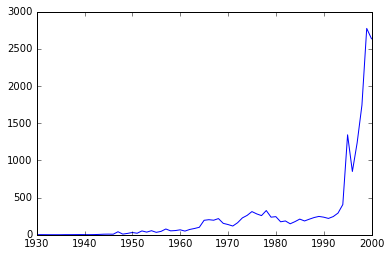

```python
# plot the number of UFO reports per year (line plot is the default)
ufo.Year.value_counts().sort_index().plot()
```

[Back to top]

## 26. How do I find and remove duplicate rows in pandas? (video)

```python
# read a dataset of movie reviewers into a DataFrame
user_cols = ['user_id', 'age', 'gender', 'occupation', 'zip_code']
users = pd.read_table('http://bit.ly/movieusers', sep='|', header=None, names=user_cols, index_col='user_id')
users.head()
```

| user_id | age | gender | occupation | zip_code |
| --- | --- | --- | --- | --- |
| 1 | 24 | M | technician | 85711 |
| 2 | 53 | F | other | 94043 |
| 3 | 23 | M | writer | 32067 |
| 4 | 24 | M | technician | 43537 |
| 5 | 33 | F | other | 15213 |

```python
users.shape
```

```
(943, 4)
```

```python
# detect duplicate zip codes: True if an item is identical to a previous item
users.zip_code.duplicated().tail()
```

```
user_id
939    False
940     True
941    False
942    False
943    False
Name: zip_code, dtype: bool
```

```python
# count the duplicate items (True becomes 1, False becomes 0)
users.zip_code.duplicated().sum()
```

```
148
```

```python
# detect duplicate DataFrame rows: True if an entire row is identical to a previous row
users.duplicated().tail()
```

```
user_id
939    False
940    False
941    False
942    False
943    False
dtype: bool
```

```python
# count the duplicate rows
users.duplicated().sum()
```

```
7
```

Logic for [**`duplicated`**](http://pandas.pydata.org/pandas-docs/stable/generated/pandas.DataFrame.duplicated.html):

- **`keep='first'`** (default): Mark duplicates as True except for the first occurrence.
- **`keep='last'`**: Mark duplicates as True except for the last occurrence.
- **`keep=False`**: Mark all duplicates as True.

```python
# examine the duplicate rows (ignoring the first occurrence)
users.loc[users.duplicated(keep='first'), :]
```

| user_id | age | gender | occupation | zip_code |
| --- | --- | --- | --- | --- |
| 496 | 21 | F | student | 55414 |
| 572 | 51 | M | educator | 20003 |
| 621 | 17 | M | student | 60402 |
| 684 | 28 | M | student | 55414 |
| 733 | 44 | F | other | 60630 |
| 805 | 27 | F | other | 20009 |
| 890 | 32 | M | student | 97301 |

```python
# examine the duplicate rows (ignoring the last occurrence)
users.loc[users.duplicated(keep='last'), :]
```

| user_id | age | gender | occupation | zip_code |
| --- | --- | --- | --- | --- |
| 67 | 17 | M | student | 60402 |
| 85 | 51 | M | educator | 20003 |
| 198 | 21 | F | student | 55414 |
| 350 | 32 | M | student | 97301 |
| 428 | 28 | M | student | 55414 |
| 437 | 27 | F | other | 20009 |
| 460 | 44 | F | other | 60630 |

```python
# examine the duplicate rows (including all duplicates)
users.loc[users.duplicated(keep=False), :]
```

| user_id | age | gender | occupation | zip_code |
| --- | --- | --- | --- | --- |
| 67 | 17 | M | student | 60402 |
| 85 | 51 | M | educator | 20003 |
| 198 | 21 | F | student | 55414 |
| 350 | 32 | M | student | 97301 |
| 428 | 28 | M | student | 55414 |
| 437 | 27 | F | other | 20009 |
| 460 | 44 | F | other | 60630 |
| 496 | 21 | F | student | 55414 |
| 572 | 51 | M | educator | 20003 |
| 621 | 17 | M | student | 60402 |
| 684 | 28 | M | student | 55414 |
| 733 | 44 | F | other | 60630 |
| 805 | 27 | F | other | 20009 |
| 890 | 32 | M | student | 97301 |

```python
# drop the duplicate rows (inplace=False by default)
users.drop_duplicates(keep='first').shape
```

```
(936, 4)
```

```python
users.drop_duplicates(keep='last').shape
```

```
(936, 4)
```

```python
users.drop_duplicates(keep=False).shape
```

```
(929, 4)
```

Documentation for [**`drop_duplicates`**](http://pandas.pydata.org/pandas-docs/stable/generated/pandas.DataFrame.drop_duplicates.html)

```python
# only consider a subset of columns when identifying duplicates
users.duplicated(subset=['age', 'zip_code']).sum()
```

```
16
```

```python
users.drop_duplicates(subset=['age', 'zip_code']).shape
```

```
(927, 4)
```

[Back to top]

## 27. How do I avoid a SettingWithCopyWarning in pandas? (video)

```python
# read a dataset of top-rated IMDb movies into a DataFrame
movies = pd.read_csv('http://bit.ly/imdbratings')
movies.head()
```

|  | star_rating | title | content_rating | genre | duration | actors_list |
| --- | --- | --- | --- | --- | --- | --- |
| 0 | 9.3 | The Shawshank Redemption | R | Crime | 142 | [u'Tim Robbins', u'Morgan Freeman', u'Bob Gunt... |
| 1 | 9.2 | The Godfather | R | Crime | 175 | [u'Marlon Brando', u'Al Pacino', u'James Caan'] |
| 2 | 9.1 | The Godfather: Part II | R | Crime | 200 | [u'Al Pacino', u'Robert De Niro', u'Robert Duv... |
| 3 | 9.0 | The Dark Knight | PG-13 | Action | 152 | [u'Christian Bale', u'Heath Ledger', u'Aaron E... |
| 4 | 8.9 | Pulp Fiction | R | Crime | 154 | [u'John Travolta', u'Uma Thurman', u'Samuel L.... |

```python
# count the missing values in the 'content_rating' Series
movies.content_rating.isnull().sum()
```

```
3
```

```python
# examine the DataFrame rows that contain those missing values
movies[movies.content_rating.isnull()]
```

|  | star_rating | title | content_rating | genre | duration | actors_list |
| --- | --- | --- | --- | --- | --- | --- |
| 187 | 8.2 | Butch Cassidy and the Sundance Kid | NaN | Biography | 110 | [u'Paul Newman', u'Robert Redford', u'Katharin... |
| 649 | 7.7 | Where Eagles Dare | NaN | Action | 158 | [u'Richard Burton', u'Clint Eastwood', u'Mary ... |
| 936 | 7.4 | True Grit | NaN | Adventure | 128 | [u'John Wayne', u'Kim Darby', u'Glen Campbell'] |

```python
# examine the unique values in the 'content_rating' Series
movies.content_rating.value_counts()
```

```
R            460
PG-13        189
PG           123
NOT RATED     65
APPROVED      47
UNRATED       38
G             32
PASSED         7
NC-17          7
X              4
GP             3
TV-MA          1
Name: content_rating, dtype: int64
```

**Goal:** Mark the 'NOT RATED' values as missing values, represented by 'NaN'.

```python
# first, locate the relevant rows
movies[movies.content_rating=='NOT RATED'].head()
```

|  | star_rating | title | content_rating | genre | duration | actors_list |
| --- | --- | --- | --- | --- | --- | --- |
| 5 | 8.9 | 12 Angry Men | NOT RATED | Drama | 96 | [u'Henry Fonda', u'Lee J. Cobb', u'Martin Bals... |
| 6 | 8.9 | The Good, the Bad and the Ugly | NOT RATED | Western | 161 | [u'Clint Eastwood', u'Eli Wallach', u'Lee Van ... |
| 41 | 8.5 | Sunset Blvd. | NOT RATED | Drama | 110 | [u'William Holden', u'Gloria Swanson', u'Erich... |
| 63 | 8.4 | M | NOT RATED | Crime | 99 | [u'Peter Lorre', u'Ellen Widmann', u'Inge Land... |
| 66 | 8.4 | Munna Bhai M.B.B.S. | NOT RATED | Comedy | 156 | [u'Sunil Dutt', u'Sanjay Dutt', u'Arshad Warsi'] |

```python
# then, select the 'content_rating' Series from those rows
movies[movies.content_rating=='NOT RATED'].content_rating.head()
```

```
5     NOT RATED
6     NOT RATED
41    NOT RATED
63    NOT RATED
66    NOT RATED
Name: content_rating, dtype: object
```

```python
# finally, replace the 'NOT RATED' values with 'NaN' (imported from NumPy)
import numpy as np
movies[movies.content_rating=='NOT RATED'].content_rating = np.nan
```

**Problem:** That statement involves two operations, a **`__getitem__`** and a **`__setitem__`**. pandas can't guarantee whether the **`__getitem__`** operation returns a view or a copy of the data.

- If **`__getitem__`** returns a view of the data, **`__setitem__`** will affect the 'movies' DataFrame.
- But if **`__getitem__`** returns a copy of the data, **`__setitem__`** will not affect the 'movies' DataFrame.

```python
# the 'content_rating' Series has not changed
movies.content_rating.isnull().sum()
```

```
3
```

**Solution:** Use the **`loc`** method, which replaces the 'NOT RATED' values in a single **`__setitem__`** operation.

```python
# replace the 'NOT RATED' values with 'NaN' (does not cause a SettingWithCopyWarning)
movies.loc[movies.content_rating=='NOT RATED', 'content_rating'] = np.nan
```

```python
# this time, the 'content_rating' Series has changed
movies.content_rating.isnull().sum()
```

```
68
```

**Summary:** Use the **`loc`** method any time you are selecting rows and columns in the same statement.

**More information:** [Modern Pandas (Part 1)](http://tomaugspurger.github.io/modern-1.html)

```python
# create a DataFrame only containing movies with a high 'star_rating'
top_movies = movies.loc[movies.star_rating >= 9, :]
top_movies
```

|  | star_rating | title | content_rating | genre | duration | actors_list |
| --- | --- | --- | --- | --- | --- | --- |
| 0 | 9.3 | The Shawshank Redemption | R | Crime | 142 | [u'Tim Robbins', u'Morgan Freeman', u'Bob Gunt... |
| 1 | 9.2 | The Godfather | R | Crime | 175 | [u'Marlon Brando', u'Al Pacino', u'James Caan'] |
| 2 | 9.1 | The Godfather: Part II | R | Crime | 200 | [u'Al Pacino', u'Robert De Niro', u'Robert Duv... |
| 3 | 9.0 | The Dark Knight | PG-13 | Action | 152 | [u'Christian Bale', u'Heath Ledger', u'Aaron E... |

**Goal:** Fix the 'duration' for 'The Shawshank Redemption'.

```python
# overwrite the relevant cell with the correct duration
top_movies.loc[0, 'duration'] = 150
```

**Problem:** pandas isn't sure whether 'top_movies' is a view or a copy of 'movies'.

```python
# 'top_movies' DataFrame has been updated
top_movies
```

|  | star_rating | title | content_rating | genre | duration | actors_list |
| --- | --- | --- | --- | --- | --- | --- |
| 0 | 9.3 | The Shawshank Redemption | R | Crime | 150 | [u'Tim Robbins', u'Morgan Freeman', u'Bob Gunt... |
| 1 | 9.2 | The Godfather | R | Crime | 175 | [u'Marlon Brando', u'Al Pacino', u'James Caan'] |
| 2 | 9.1 | The Godfather: Part II | R | Crime | 200 | [u'Al Pacino', u'Robert De Niro', u'Robert Duv... |
| 3 | 9.0 | The Dark Knight | PG-13 | Action | 152 | [u'Christian Bale', u'Heath Ledger', u'Aaron E... |

```python
# 'movies' DataFrame has not been updated
movies.head(1)
```

|  | star_rating | title | content_rating | genre | duration | actors_list |
| --- | --- | --- | --- | --- | --- | --- |
| 0 | 9.3 | The Shawshank Redemption | R | Crime | 142 | [u'Tim Robbins', u'Morgan Freeman', u'Bob Gunt... |

**Solution:** Any time you are attempting to create a DataFrame copy, use the [**`copy`**](http://pandas.pydata.org/pandas-docs/stable/generated/pandas.DataFrame.copy.html) method.

```python
# explicitly create a copy of 'movies'
top_movies = movies.loc[movies.star_rating >= 9, :].copy()
```

```python
# pandas now knows that you are updating a copy instead of a view (does not cause a SettingWithCopyWarning)
top_movies.loc[0, 'duration'] = 150
```

```python
# 'top_movies' DataFrame has been updated
top_movies
```

|  | star_rating | title | content_rating | genre | duration | actors_list |
| --- | --- | --- | --- | --- | --- | --- |
| 0 | 9.3 | The Shawshank Redemption | R | Crime | 150 | [u'Tim Robbins', u'Morgan Freeman', u'Bob Gunt... |
| 1 | 9.2 | The Godfather | R | Crime | 175 | [u'Marlon Brando', u'Al Pacino', u'James Caan'] |
| 2 | 9.1 | The Godfather: Part II | R | Crime | 200 | [u'Al Pacino', u'Robert De Niro', u'Robert Duv... |
| 3 | 9.0 | The Dark Knight | PG-13 | Action | 152 | [u'Christian Bale', u'Heath Ledger', u'Aaron E... |

Documentation on indexing and selection: [Returning a view versus a copy](http://pandas.pydata.org/pandas-docs/stable/indexing.html#indexing-view-versus-copy)

Stack Overflow: [What is the point of views in pandas if it is undefined whether an indexing operation returns a view or a copy?](http://stackoverflow.com/questions/34884536/what-is-the-point-of-views-in-pandas-if-it-is-undefined-whether-an-indexing-oper)

[Back to top]